# Introduction

In this report we try to answer a series of questions on how we could reduce CO$^{2}$ emissions by making changes to how we commute around Ireland.

We collected data, cleaned it, then conducted a series of exploration and visualisation of our data. We identified a particular subset of our data to drill down into so we could extract details to explain current habits causing CO$^{2}$ emissions and what we could do to lower them.

This report first defines the problem we are trying to tackle. It then gives a brief overview of each dataset and where they were collected from. We then go through an iterative process of cleaning and selecting features to create a workable dataset. Once we have a cleaned dataset this report provides visuals of our data to analyse. At the bottom of each graph we try make some observations on the data to help us identify a particular subset of our data to further examine. With a particular subset we then try to answer questions and return a list of recommendations which could help reduce CO$^{2}$ emissions.

## Problem definition

The [european protection agency, 2021](https://www.epa.ie/environment-and-you/climate-change/what-impact-will-climate-change-have-for-ireland/) stated that "human activities are estimated to have caused approximately 1.0°C of global warming above pre-industrial levels with a likely range of 0.8°C to 1.2°C". The EPA believes we are on course to exceed the paris climate agreement of remaining between 1.5°C to 2°C above pre-industrial levels. This will impact ireland from a decrease in frequency of summer rain fall and an increase in of heavy winter rain, it will change wind strength and put stress on crops. Rising sea levels will cause coastal erosion, flooding and damage to both infastructure or propery in all major cities in Ireland that are located near the coast.This would affect the Irish economy, human health and wellbeing.

According to the [Sustainability Energy Authority of Ireland (SEAI), 2021)](https://www.seai.ie/data-and-insights/seai-statistics/key-statistics/co2/) transportation accounts for 40% of our kilo tonne of C02 put into the atmosphere.

Reducing the number of petrol and diesel vehicles on Irish roads could reduce this 40% figure. Ways to reduce the number of vehicles on the road are for commuters to change to electric vehicles, cycle more or use public transport.

This report will look at

- Different modes of transport for people in ireland
- Understanding from the data what makes people choose personal transport over public transport.
- Investigate, from the data, how to increase public transport usage.

The following data visualisation was inspired on data analysis related to Chicago Transit data such as work by [(Reid, 2018)](https://towardsdatascience.com/exploring-and-visualizing-chicago-transit-data-using-pandas-and-bokeh-part-i-intro-to-pandas-5d6caa8813ef)

## About Dataset

The following 10 data sets are based on mobility in Ireland and were taken from the Central Statistics Office (CSO) on [Commuting in Ireland](https://www.cso.ie/en/releasesandpublications/ep/p-cp6ci/p6cii/p6mtw/) via their interactive API portal. The data was collected from [various census surveys](https://www.cso.ie/en/releasesandpublications/ep/p-cp6ci/p6cii/p6bgn/) conducted in Ireland. Each data set is stored in a folder called /data/.

- [E6010_mobility_by_past30yrs](http://www.cso.ie/px/pxeirestat/Statire/SelectVarVal/Define.asp?maintable=E6010&PLanguage=0)
- [E6038_people_at_work](http://www.cso.ie/px/pxeirestat/Statire/SelectVarVal/Define.asp?maintable=E6038&PLanguage=0)
- [E6043_mobility_by_class](http://www.cso.ie/px/pxeirestat/Statire/SelectVarVal/Define.asp?maintable=E6043&PLanguage=0)
- [E6006_travel_duration](http://www.cso.ie/px/pxeirestat/Statire/SelectVarVal/Define.asp?maintable=E6006&PLanguage=0)
- [E6013_mobility_by_geo](http://www.cso.ie/px/pxeirestat/Statire/SelectVarVal/Define.asp?maintable=E6013&PLanguage=0)
- [E6040_travel_time_by_age](http://www.cso.ie/px/pxeirestat/Statire/SelectVarVal/Define.asp?maintable=E6040&PLanguage=0)
- [E6016.mobility_by_students](http://www.cso.ie/px/pxeirestat/Statire/SelectVarVal/Define.asp?maintable=E6016&PLanguage=0)
- [E6034.people_working_in_towns_suburbs](http://www.cso.ie/px/pxeirestat/Statire/SelectVarVal/Define.asp?maintable=E6034&PLanguage=0)
- [E6018.mobility_by_students_from_towns](http://www.cso.ie/px/pxeirestat/Statire/SelectVarVal/Define.asp?maintable=E6018&PLanguage=0)
- [E6023.mobility_by_students_from_geo](http://www.cso.ie/px/pxeirestat/Statire/SelectVarVal/Define.asp?maintable=E6023&PLanguage=0)

*further descriptions about columns can be found here

# Part 1 - Data Cleaning

### Import libaries

```python
# ensure using python3
# ensure following installed first:
    #pip install numpy
    #pip install pandas
    #pip install matplotlib
    #pip install seaborn

import numpy as np #used to efficiently handle data in memory
import pandas as pd #used to handle datasets
import matplotlib.pyplot as plt #used for visuals + analysis
import seaborn as sns # expands featureset and simplifies matplotlib
import warnings
import re # used to perform regular expression searching
import csv # used to do manual work with csv files outside of pandas
from scipy.stats import chi2_contingency

warnings.filterwarnings('ignore')# filter unwanted warnings
#ensures we show graphs in our notebook
%matplotlib inline
%reload_ext autoreload
%autoreload 2
```

## Import raw csv files

```python
#Each dataset could answer a question

#How has commuting in Ireland changed from 1986 to 2016?
df_mobility_by_past30yrs = pd.read_csv (r'./data/E6010_mobility_by_past30yrs.csv')

#Who is at work?
df_people_at_work = pd.read_csv (r'./data/E6038_people_at_work.csv')

#Which class of people are travelling to work and how are they doing it?
df_mobility_by_class = pd.read_csv (r'./data/E6043_mobility_by_class.csv')

#How long does it take to get from A to B?
df_travel_duration = pd.read_csv (r'./data/E6006_travel_duration.csv')

#Where are people communiting from?
df_mobility_by_geo = pd.read_csv (r'./data/E6013_mobility_by_geo.csv')

#How old are irish commuters?
df_travel_time_by_age = pd.read_csv (r'./data/E6040_travel_time_by_age.csv')

#How do students get around?
df_mobility_by_students = pd.read_csv (r'./data/E6016.mobility_by_students.csv')
#Who is not working in cities?
df_people_working_in_towns_suburbs = pd.read_csv (r'./data/E6034.people_working_in_towns_suburbs.csv')

#How do students get from towns to cities
df_mobility_by_students_from_towns = pd.read_csv (r'./data/E6018.mobility_by_students_from_towns.csv')

#How do students get from county to county
df_mobility_by_students_from_geo = pd.read_csv (r'./data/E6023.mobility_by_students_from_geo.csv')
```

We will go through each dataset with a mix of exploring the data and cleaning it. Once cleaned we will do a deeper data exploration. The first two datasets will be discussed step by step then the rest will be processed in bulk.

## Cleaning Dataset 1 : df_mobility_by_past30yrs

### Select the dataset

```python
#we pick a dataset to look at and we clean it
df = df_mobility_by_past30yrs
#get header names but keep column order
list(df.columns.values)# we have 7 columns here with different formats.
```

```
['Statistic',
 'CensusYear',
 'Sex',
 'Means of Travel',
 'At Work School or College',
 'UNIT',
 'VALUE']
```

### Examine dataset's shape, values & descriptive statistics

```python
# check the count of rows and columns using shape
df.shape # (rows, cols) # we have 1155 observations with 7 features
```

```
(1155, 7)
```

```python
#look at top of dataset
df.head(10)
# we take a look at first 10, we see that long text is used to describe simple categories
```

|  | Statistic | CensusYear | Sex | Means of Travel | At Work School or College | UNIT | VALUE |
| --- | --- | --- | --- | --- | --- | --- | --- |
| 0 | Population Usually Resident in the State at Ea... | 1986 | Both sexes | On foot | All persons | Number | 505530 |
| 1 | Population Usually Resident in the State at Ea... | 1986 | Both sexes | On foot | Population aged 15 years and over at work | Number | 136000 |
| 2 | Population Usually Resident in the State at Ea... | 1986 | Both sexes | On foot | Children at school aged between 5 and 12 years | Number | 251947 |
| 3 | Population Usually Resident in the State at Ea... | 1986 | Both sexes | On foot | Students at school or college aged between 13 ... | Number | 105292 |
| 4 | Population Usually Resident in the State at Ea... | 1986 | Both sexes | On foot | Students at school or college aged 19 years an... | Number | 12291 |
| 5 | Population Usually Resident in the State at Ea... | 1986 | Both sexes | Bicycle | All persons | Number | 146962 |
| 6 | Population Usually Resident in the State at Ea... | 1986 | Both sexes | Bicycle | Population aged 15 years and over at work | Number | 60750 |
| 7 | Population Usually Resident in the State at Ea... | 1986 | Both sexes | Bicycle | Children at school aged between 5 and 12 years | Number | 23635 |
| 8 | Population Usually Resident in the State at Ea... | 1986 | Both sexes | Bicycle | Students at school or college aged between 13 ... | Number | 50648 |
| 9 | Population Usually Resident in the State at Ea... | 1986 | Both sexes | Bicycle | Students at school or college aged 19 years an... | Number | 11929 |

```python
#look at bottom of data set
df.tail(10) # we see missing values disguised as 'not stated'
```

|  | Statistic | CensusYear | Sex | Means of Travel | At Work School or College | UNIT | VALUE |
| --- | --- | --- | --- | --- | --- | --- | --- |
| 1145 | Population Usually Resident in the State at Ea... | 2016 | Female | Not stated | All persons | Number | 61919 |
| 1146 | Population Usually Resident in the State at Ea... | 2016 | Female | Not stated | Population aged 15 years and over at work | Number | 41070 |
| 1147 | Population Usually Resident in the State at Ea... | 2016 | Female | Not stated | Children at school aged between 5 and 12 years | Number | 12479 |
| 1148 | Population Usually Resident in the State at Ea... | 2016 | Female | Not stated | Students at school or college aged between 13 ... | Number | 5118 |
| 1149 | Population Usually Resident in the State at Ea... | 2016 | Female | Not stated | Students at school or college aged 19 years an... | Number | 3252 |
| 1150 | Population Usually Resident in the State at Ea... | 2016 | Female | All means of travel | All persons | Number | 1451038 |
| 1151 | Population Usually Resident in the State at Ea... | 2016 | Female | All means of travel | Population aged 15 years and over at work | Number | 913163 |
| 1152 | Population Usually Resident in the State at Ea... | 2016 | Female | All means of travel | Children at school aged between 5 and 12 years | Number | 267251 |
| 1153 | Population Usually Resident in the State at Ea... | 2016 | Female | All means of travel | Students at school or college aged between 13 ... | Number | 172315 |
| 1154 | Population Usually Resident in the State at Ea... | 2016 | Female | All means of travel | Students at school or college aged 19 years an... | Number | 98309 |

```python
#get number of observations, coumn names and look for any empty cells, check data types.
df.info() # we have 5 categorical variables and two numeric variables
```

```
<class 'pandas.core.frame.DataFrame'>
RangeIndex: 1155 entries, 0 to 1154
Data columns (total 7 columns):
 #   Column                     Non-Null Count  Dtype
---  ------                     --------------  -----
 0   Statistic                  1155 non-null   object
 1   CensusYear                 1155 non-null   int64
 2   Sex                        1155 non-null   object
 3   Means of Travel            1155 non-null   object
 4   At Work School or College  1155 non-null   object
 5   UNIT                       1155 non-null   object
 6   VALUE                      1155 non-null   int64
dtypes: int64(2), object(5)
memory usage: 63.3+ KB
```

### Clean column headers

```python
#loop through columns, remove white spaces
#this is to help accessing values later

def format_columns(data_frame):
    formated_names = {}
    for col_name in data_frame.columns:
        name = col_name.lower() # could also have used df = df.rename(str.lower, axis='columns')
        name = name.replace(' ', '_')
        formated_names[col_name] = name
    return data_frame.rename(columns=formated_names)

df = format_columns(df)
df.info()
```

```
<class 'pandas.core.frame.DataFrame'>
RangeIndex: 1155 entries, 0 to 1154
Data columns (total 7 columns):
 #   Column                     Non-Null Count  Dtype
---  ------                     --------------  -----
 0   statistic                  1155 non-null   object
 1   censusyear                 1155 non-null   int64
 2   sex                        1155 non-null   object
 3   means_of_travel            1155 non-null   object
 4   at_work_school_or_college  1155 non-null   object
 5   unit                       1155 non-null   object
 6   value                      1155 non-null   int64
dtypes: int64(2), object(5)
memory usage: 63.3+ KB
```

### Correct format for categorical and numeric features

```python
#loop through columns if data type is object convert it to category
def categorise_objects(data_frame):
    for col_name in data_frame.columns:
        dt = data_frame.dtypes[col_name]
        if dt == object:
            data_frame[col_name] = data_frame[col_name].astype('category')
    return data_frame

df = categorise_objects(df)
df.info()
```

```
<class 'pandas.core.frame.DataFrame'>
RangeIndex: 1155 entries, 0 to 1154
Data columns (total 7 columns):
 #   Column                     Non-Null Count  Dtype
---  ------                     --------------  -----
 0   statistic                  1155 non-null   category
 1   censusyear                 1155 non-null   int64
 2   sex                        1155 non-null   category
 3   means_of_travel            1155 non-null   category
 4   at_work_school_or_college  1155 non-null   category
 5   unit                       1155 non-null   category
 6   value                      1155 non-null   int64
dtypes: category(5), int64(2)
memory usage: 24.8 KB
```

### Drill down into dataset values

```python
#Look to see what unique values are in each column
# idea here is to see what can be dropped and what can be kept
def list_unique_cats(data_frame):
    for col_name in df.columns:
        print("\n" + col_name)
        print(df[col_name].unique())
list_unique_cats(df)
```

```
statistic
['Population Usually Resident in the State at E...]
Categories (1, object): ['Population Usually Resident in the State at E...]

censusyear
[1986 1991 1996 2002 2006 2011 2016]

sex
['Both sexes', 'Male', 'Female']
Categories (3, object): ['Both sexes', 'Female', 'Male']

means_of_travel
['On foot', 'Bicycle', 'Bus, minibus or coach', 'Train, DART or LUAS', 'Motorcycle or scooter', ..., 'Motor car: Passenger', 'Other means (incl. lorry or van)', 'Work mainly at or from home', 'Not stated', 'All means of travel']
Length: 11
Categories (11, object): ['All means of travel', 'Bicycle', 'Bus, minibus or coach', 'Motor car: Driver', ..., 'On foot', 'Other means (incl. lorry or van)', 'Train, DART or LUAS', 'Work mainly at or from home']

at_work_school_or_college
['All persons', 'Population aged 15 years and over at work', 'Children at school aged between 5 and 12 years', 'Students at school or college aged between 13..., 'Students at school or college aged 19 years a...]
Categories (5, object): ['All persons', 'Children at school aged between 5 and 12 years', 'Population aged 15 years and over at work', 'Students at school or college aged 19 years a..., 'Students at school or college aged between 13...]

unit
['Number']
Categories (1, object): ['Number']

value
[505530 136000 251947 ... 267251 172315  98309]
```

### Dataset 1: mobility_by_past30yrs dataset description

The following is a brief description of each feature in this dataset.

1. Statistic column only has 1 value which is not useful to us. We will remove this.
2. Census Year is important it is a date range for 7 different census surveys taken over 30 years
3. Sex
- has 3 options one is called 'Both Sexes'
- 'Both Sexes'was renamed to all via df = df.replace({'Both sexes': 'all'})
- when viewing dataset it appears to be a summation of other columns.
- any 'all' in dataset will be removed.
1. Means of Travel
- has 'not stated and 'all means of travel'
- 'all means of travel' was renamed to all via df = df.replace({'Both sexes': 'all'})
- any 'all' in dataset will be removed.
- motor car has both a driver and a passenger option
- some names could be changed for brevity, e.g
  - All means of travel -> all
  - Work mainly at or from home -> remote work
  - On foot -> walking
  - bicycle -> bike
  - Bus, minibus or coach -> bus
  - Motorcycle or scooter -> motorbike
  - Motor car: Driver -> car
  - Motor car: Passenger -> carpool
  - Other means (incl. lorry or van) - truck
1. At Work School or College
- this column shows the level of education a person has
- but it also contains age data
- we could seperate these two into a new column age and edu_level
- this seperation would be based on info available from [citizens information](https://www.citizensinformation.ie/en/education/the_irish_education_system/overview_of_the_irish_education_system.html)
- we can also make use of retirement age of 66 for range https://www.citizensinformation.ie/en/employment/retirement/older_people_and_working/retirement_age_in_ireland.html
- Although the oldest person to graduate in ireland was 82 after starting university in 2017 at 79, we will assume those stated in university are aged between 19 to 66 https://www.independent.ie/regionals/newrossstandard/irelands-oldest-student-tom-thrilled-to-collect-degree-38638703.html
- 'all persons' could be removed or held as a seperate database
- 'all persons' isn't describe clearly. e.g Is the person has no education or is 89 years old?
  - some names could be changed for brevity as well, e.g
    - 'All persons',
    - 'Children at school aged between 5 and 12 years', 5-12 | primary-school
    - 'Population aged 15 years and over at work', >=15 | junior-cert
    - 'Students at school or college aged between 13 and 18 years', 13-18 | leaving-cert
    - 'Students at school or college aged 19 years a...', 19-up | university
1. Unit
- supposed to be if the unit of measure is km, mins, etc but for this dataset it is just number
- since one number we will remove
1. Value
- is number of people we will keep

#### Further data cleaning, and feature engineering

```python
#we can now format columns (e.g drop a column or seperate a column)
df = df.drop('statistic', axis=1) # axis 0 will drop label, 1 will drop column
df = df.rename(columns={'censusyear':'year'})#we can drop census from name of column
df = df.replace({'Both sexes': 'all'}) #we rename 'Both sexes' values to 'all'
#rename means of travel
df['means_of_travel'] = df['means_of_travel'].cat.rename_categories({
    'On foot': 'walking',
    'Bicycle': 'bike',
    'Bus, minibus or coach': 'bus',
    'Train, DART or LUAS': 'train',
    'Motorcycle or scooter': 'motorbike',
    'Motor car: Driver': 'car',
    'Motor car: Passenger': 'carpool',
    'Other means (incl. lorry or van)': 'truck',
    'Work mainly at or from home' : 'remote',
    'All means of travel' : 'all',
    'Not stated' : 'na'
})

#split out at_work_school_or_college
age_range = []
edu_status = []
for value in df['at_work_school_or_college']:
    if value == "All persons":
        age_range.append("all")
        edu_status.append("all")
    elif value == "Children at school aged between 5 and 12 years":
        age_range.append("5-12")
        edu_status.append("at primary school")
    elif value == "Population aged 15 years and over at work":
        age_range.append("15-66")
        edu_status.append("working")
    elif value == "Students at school or college aged between 13 and 18 years":
        age_range.append("13-18")
        edu_status.append("at secondary school")
    elif value == "Students at school or college aged 19 years and over":
        age_range.append("19-66")
        edu_status.append("at university")
df['age_range'] = age_range
df['edu_status'] = edu_status

#we now don't need this column anymore
df = df.drop('at_work_school_or_college', axis=1)

#we can drop units
df = df.drop('unit', axis=1)

#now we remove every 'all' row
df = df[df.sex != 'all']
df = df[df.means_of_travel != 'all']
df = df[df.age_range != 'all']
df = df[df.edu_status != 'all']

#rearange columns so value is at end
df = df[['year', 'sex', 'means_of_travel', 'age_range', 'edu_status', 'value']]
```

#### Fixing missing values

```python
df.tail()
```

|  | year | sex | means_of_travel | age_range | edu_status | value |
| --- | --- | --- | --- | --- | --- | --- |
| 1144 | 2016 | Female | remote | 19-66 | at university | 349 |
| 1146 | 2016 | Female | na | 15-66 | working | 41070 |
| 1147 | 2016 | Female | na | 5-12 | at primary school | 12479 |
| 1148 | 2016 | Female | na | 13-18 | at secondary school | 5118 |
| 1149 | 2016 | Female | na | 19-66 | at university | 3252 |

```
<BarContainer object of 56 artists>
```

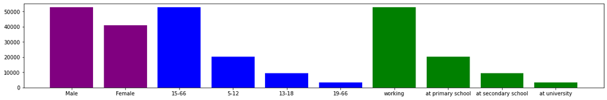

```python
# review of missing 'means of travel' in each column
df_missing = df.loc[df['means_of_travel'] == 'na'] #sort by na's
plt.figure(figsize=(20, 3)) #used to space out x axis columns
plt.bar(df_missing.sex, df_missing.value, color='purple')
plt.bar(df_missing.age_range, df_missing.value, color='blue')
plt.bar(df_missing.edu_status, df_missing.value, color='green')
```

```python
df_missing.describe()
```

|  | year | value |
| --- | --- | --- |
| count | 56.000000 | 56.000000 |
| mean | 2001.142857 | 10904.803571 |
| std | 10.096676 | 10982.288659 |
| min | 1986.000000 | 1003.000000 |
| 25% | 1991.000000 | 2788.000000 |
| 50% | 2002.000000 | 7209.500000 |
| 75% | 2011.000000 | 16960.250000 |
| max | 2016.000000 | 52639.000000 |

```python
df_cleaned = df.loc[df['means_of_travel'] != 'na']
```

```python
df_cleaned.describe()
```

|  | year | value |
| --- | --- | --- |
| count | 504.000000 | 504.000000 |
| mean | 2001.142857 | 33501.015873 |
| std | 10.016062 | 75254.412024 |
| min | 1986.000000 | 0.000000 |
| 25% | 1991.000000 | 719.250000 |
| 50% | 2002.000000 | 6545.500000 |
| 75% | 2011.000000 | 40719.250000 |
| max | 2016.000000 | 590927.000000 |

```python
per_missing = (df_missing.shape[0]/(df_cleaned.shape[0]+df_missing.shape[0])) * 100
print("missing: " + str(per_missing) + "% of data missing")#missing is only 10% of dataset
df = df_cleaned #removed missing
```

```
missing: 10.0% of data missing
```

```python
#now we save our clean dataset to use later for visualisation
df.to_csv(r'./data/E6010_mobility_by_past30yrs_cleaned.csv', index=False) #we don't want an auto index

#test we saved successfully
df_test = pd.read_csv (r'./data/E6010_mobility_by_past30yrs_cleaned.csv')
```

```python
df_test.head(10)
```

|  | year | sex | means_of_travel | age_range | edu_status | value |
| --- | --- | --- | --- | --- | --- | --- |
| 0 | 1986 | Male | walking | 15-66 | working | 69916 |
| 1 | 1986 | Male | walking | 5-12 | at primary school | 129973 |
| 2 | 1986 | Male | walking | 13-18 | at secondary school | 50585 |
| 3 | 1986 | Male | walking | 19-66 | at university | 5932 |
| 4 | 1986 | Male | bike | 15-66 | working | 39469 |
| 5 | 1986 | Male | bike | 5-12 | at primary school | 14507 |
| 6 | 1986 | Male | bike | 13-18 | at secondary school | 31522 |
| 7 | 1986 | Male | bike | 19-66 | at university | 7290 |
| 8 | 1986 | Male | bus | 15-66 | working | 41878 |
| 9 | 1986 | Male | bus | 5-12 | at primary school | 52928 |

```python
def skewness_kurtosis(data_frame):
    #ref https://medium.com/@atanudan/kurtosis-skew-function-in-pandas-aa63d72e20de
    skew = data_frame['value'].skew(axis=0)
    #data skewness - helps us determine what models are suitable (e.g regession models like normal distribution)
    print("Skew: ")
    print(skew)
    if(-0.5 > skew < 0.5):
        print("data is fairly symmetrical\n")
    elif(-1.0 > skew < -0.5 or 0.5 > skew <1.0):
        print("data is moderately skewed\n")
    elif(-1.0 < skew > 1.0):
        print("data is highly skewed\n")

    #data kurtosis - used to find outliers
    kurt = data_frame['value'].kurt(axis=0)
    print("Kurtosis: ")
    print(kurt)
    if(3.0 < kurt):
        print("data has a leptokurtic distribution(tall+thin)\n")
    elif( 3.0 > kurt):
        print("data has a platykurtic distribution(Moderately Spread Out)\n")
    elif(kurt == 3.0):
        print("data has a mesokurtic distribution(similar to normal distribution)\n")

skewness_kurtosis(df_test)
```

```
Skew:
5.100932693490345
data is highly skewed

Kurtosis:
30.22457678237505
data has a leptokurtic distribution(tall+thin)
```

## Cleaning Dataset 2 : df_people_at_work

In this section we do the same tasks as previous. The outline of each section will be shortened.

### Select dataset & look at data shape, values and descriptive statistics

```python
df = df_people_at_work
#get header names but keep column order
list(df.columns.values)# we have 6 columns here with different formats.
```

```
['Statistic',
 'CensusYear',
 'Principal Economic Status',
 'Sex',
 'UNIT',
 'VALUE']
```

```python
# check the count of rows and columns using shape
df.shape # (rows, cols) # we have 12 observations with 6 features
```

```
(12, 6)
```

```python
#look at top of dataset
df.head(10)
# we take a look at first 10, we see again that long text is used to describe simple categories
```

|  | Statistic | CensusYear | Principal Economic Status | Sex | UNIT | VALUE |
| --- | --- | --- | --- | --- | --- | --- |
| 0 | Population aged 15 Years and Over at Work, Usu... | 2016 | Population aged 15 years and over at work | Both sexes | Number | 1970728 |
| 1 | Population aged 15 Years and Over at Work, Usu... | 2016 | Population aged 15 years and over at work | Male | Number | 1057565 |
| 2 | Population aged 15 Years and Over at Work, Usu... | 2016 | Population aged 15 years and over at work | Female | Number | 913163 |
| 3 | Population aged 15 Years and Over at Work, Usu... | 2016 | Employer or own account worker | Both sexes | Number | 308411 |
| 4 | Population aged 15 Years and Over at Work, Usu... | 2016 | Employer or own account worker | Male | Number | 238430 |
| 5 | Population aged 15 Years and Over at Work, Usu... | 2016 | Employer or own account worker | Female | Number | 69981 |
| 6 | Population aged 15 Years and Over at Work, Usu... | 2016 | Employee | Both sexes | Number | 1657744 |
| 7 | Population aged 15 Years and Over at Work, Usu... | 2016 | Employee | Male | Number | 816943 |
| 8 | Population aged 15 Years and Over at Work, Usu... | 2016 | Employee | Female | Number | 840801 |
| 9 | Population aged 15 Years and Over at Work, Usu... | 2016 | Assisting relative | Both sexes | Number | 4573 |

```python
#look at bottom of data set
df.tail(10)
# we don't see missing values disguised as 'not stated' we do see all for 'both sexes'
#again statistic and unit could be removed
#column headers could be reformatted
```

|  | Statistic | CensusYear | Principal Economic Status | Sex | UNIT | VALUE |
| --- | --- | --- | --- | --- | --- | --- |
| 2 | Population aged 15 Years and Over at Work, Usu... | 2016 | Population aged 15 years and over at work | Female | Number | 913163 |
| 3 | Population aged 15 Years and Over at Work, Usu... | 2016 | Employer or own account worker | Both sexes | Number | 308411 |
| 4 | Population aged 15 Years and Over at Work, Usu... | 2016 | Employer or own account worker | Male | Number | 238430 |
| 5 | Population aged 15 Years and Over at Work, Usu... | 2016 | Employer or own account worker | Female | Number | 69981 |
| 6 | Population aged 15 Years and Over at Work, Usu... | 2016 | Employee | Both sexes | Number | 1657744 |
| 7 | Population aged 15 Years and Over at Work, Usu... | 2016 | Employee | Male | Number | 816943 |
| 8 | Population aged 15 Years and Over at Work, Usu... | 2016 | Employee | Female | Number | 840801 |
| 9 | Population aged 15 Years and Over at Work, Usu... | 2016 | Assisting relative | Both sexes | Number | 4573 |
| 10 | Population aged 15 Years and Over at Work, Usu... | 2016 | Assisting relative | Male | Number | 2192 |
| 11 | Population aged 15 Years and Over at Work, Usu... | 2016 | Assisting relative | Female | Number | 2381 |

```python
#get number of observations, column names and look for any empty cells, check data types.
df.info() # we have 4 categorical variables and two numeric variables
```

```
<class 'pandas.core.frame.DataFrame'>
RangeIndex: 12 entries, 0 to 11
Data columns (total 6 columns):
 #   Column                     Non-Null Count  Dtype
---  ------                     --------------  -----
 0   Statistic                  12 non-null     object
 1   CensusYear                 12 non-null     int64
 2   Principal Economic Status  12 non-null     object
 3   Sex                        12 non-null     object
 4   UNIT                       12 non-null     object
 5   VALUE                      12 non-null     int64
dtypes: int64(2), object(4)
memory usage: 704.0+ bytes
```

```python
#loop through columns, remove white spaces
#this is to help accessing values later
df = format_columns(df)#our custom function for formatting dataframes
df.info()
```

```
<class 'pandas.core.frame.DataFrame'>
RangeIndex: 12 entries, 0 to 11
Data columns (total 6 columns):
 #   Column                     Non-Null Count  Dtype
---  ------                     --------------  -----
 0   statistic                  12 non-null     object
 1   censusyear                 12 non-null     int64
 2   principal_economic_status  12 non-null     object
 3   sex                        12 non-null     object
 4   unit                       12 non-null     object
 5   value                      12 non-null     int64
dtypes: int64(2), object(4)
memory usage: 704.0+ bytes
```

```python
#loop through columns if data type is object convert it to category
df = categorise_objects(df)#our custom function for categorising dataframes
df.info()
```

```
<class 'pandas.core.frame.DataFrame'>
RangeIndex: 12 entries, 0 to 11
Data columns (total 6 columns):
 #   Column                     Non-Null Count  Dtype
---  ------                     --------------  -----
 0   statistic                  12 non-null     category
 1   censusyear                 12 non-null     int64
 2   principal_economic_status  12 non-null     category
 3   sex                        12 non-null     category
 4   unit                       12 non-null     category
 5   value                      12 non-null     int64
dtypes: category(4), int64(2)
memory usage: 936.0 bytes
```

```python
list_unique_cats(df)#our custom function for viewing each category value
```

```
statistic
['Population aged 15 Years and Over at Work, Us...]
Categories (1, object): ['Population aged 15 Years and Over at Work, Us...]

censusyear
[2016]

principal_economic_status
['Population aged 15 years and over at work', 'Employer or own account worker', 'Employee', 'Assisting relative']
Categories (4, object): ['Assisting relative', 'Employee', 'Employer or own account worker', 'Population aged 15 years and over at work']

sex
['Both sexes', 'Male', 'Female']
Categories (3, object): ['Both sexes', 'Female', 'Male']

unit
['Number']
Categories (1, object): ['Number']

value
[1970728 1057565  913163  308411  238430   69981 1657744  816943  840801
    4573    2192    2381]
```

### Dataset 2: people_at_work dataset description

```
<BarContainer object of 3 artists>
```

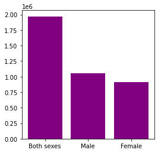

```python
# review of all 'principal_economic_status' in each column
df_all = df.loc[df['principal_economic_status'] == 'Population aged 15 years and over at work'] #sort by all's
plt.figure(figsize=(4, 4)) #used to space out x axis columns
plt.bar(df_all.sex, df_all.value, color='purple')
#again all is a sumation of other columns. this will be removed from our dataset
```

- Statistic column like before only has 1 value which is not useful to us. We will remove this.
- Census Year like before is important but it is only for census survey taken in 2016
- principal_economic_status
  - could be simplified
  - 'Population aged 15 years and over at work' => 'all' because it's the summation of other rows
  - 'all' will be removed
- sex
  - similar to before 'all sex'

```python
#we can now format columns (e.g drop a column or seperate a column)
df = df.drop('statistic', axis=1) # axis 0 will drop label, 1 will drop column
df = df.rename(columns={'censusyear':'year'})#we can drop census from name of column
df = df.replace({'Both sexes': 'all'}) #we rename 'Both sexes' values to 'all'
#rename means of travel
df['principal_economic_status'] = df['principal_economic_status'].cat.rename_categories({
    'Population aged 15 years and over at work': 'all',
    'Employer or own account worker': 'self-employed',
    'Employee': 'employee',
    'Assisting relative': 'carer',
})

#we can drop unit like before
df = df.drop('unit', axis=1)

#now we remove every 'all' row
df = df[df.principal_economic_status != 'all']
df = df[df.sex != 'all']

#rearange columns so value is at end
df = df[['year', 'principal_economic_status', 'sex', 'value']]
```

```python
#now we save our clean dataset to use later for visualisation
df.to_csv(r'./data/E6038_people_at_work_cleaned.csv', index=False) #we don't want an auto index

#test we saved successfully
df_test = pd.read_csv (r'./data/E6038_people_at_work_cleaned.csv')
```

```python
df_test.head(10)
```

|  | year | principal_economic_status | sex | value |
| --- | --- | --- | --- | --- |
| 0 | 2016 | self-employed | Male | 238430 |
| 1 | 2016 | self-employed | Female | 69981 |
| 2 | 2016 | employee | Male | 816943 |
| 3 | 2016 | employee | Female | 840801 |
| 4 | 2016 | carer | Male | 2192 |
| 5 | 2016 | carer | Female | 2381 |

```python
df_test.tail()
```

|  | year | principal_economic_status | sex | value |
| --- | --- | --- | --- | --- |
| 1 | 2016 | self-employed | Female | 69981 |
| 2 | 2016 | employee | Male | 816943 |
| 3 | 2016 | employee | Female | 840801 |
| 4 | 2016 | carer | Male | 2192 |
| 5 | 2016 | carer | Female | 2381 |

```python
skewness_kurtosis(df_test)
```

```
Skew:
0.7835310646216856
Kurtosis:
-1.9465100643263051
data has a platykurtic distribution(Moderately Spread Out)
```

the following will be a summerised version of the last two dataset analysis and cleanup

## Cleaning Dataset 3 : df_mobility_by_class

```python
#we pick a dataset to look at and we clean it
df = df_mobility_by_class
#get header names but keep column order
list(df.columns.values)
#loop through columns, remove white spaces
#this is to help accessing values later
df = format_columns(df)#our custom function for formatting dataframes
#loop through columns if data type is object convert it to category
df = categorise_objects(df)#our custom function for categorising dataframes
list_unique_cats(df)#our custom function for viewing each category value
#we can now format columns (e.g drop a column or seperate a column)

#descriptions of dataset
    #social_class - what level of skill and pay someone gets for their profession
#clean dataset
df = df.drop('statistic', axis=1) # axis 0 will drop label, 1 will drop column
df = df.rename(columns={'censusyear':'year'})#we can drop census from name of column
df = df.replace({'All social classes': 'all'}) #we rename 'Both sexes' values to 'all'
#rename means of travel
df['social_class'] = df['social_class'].cat.rename_categories({
    'Professional workers': 'self-employed',
    'Managerial and technical': 'employed-managerial',
    'Non-manual': 'employed-admin-workers',
    'Skilled manual': 'trade-workers',
    'Semi-skilled': 'manual-workers',
    'All other gainfully occupied and unknown': 'unemployed',

})

#rename means of travel
df['means_of_travel'] = df['means_of_travel'].cat.rename_categories({
    'On foot': 'walking',
    'Bicycle': 'bike',
    'Bus, minibus or coach': 'bus',
    'Train, DART or LUAS': 'train',
    'Motorcycle or scooter': 'motorbike',
    'Motor car: Driver': 'car',
    'Motor car: Passenger': 'carpool',
    'Other, incl. lorry': 'truck', #we remove brackets to detect this value
    'Work mainly at or from home' : 'remote',
    'All means of travel' : 'all',
    'Not stated' : 'na'
})

#we need to combine van to truck
df = df.replace({'Van': 'truck'}) #we rename 'Both sexes' values to 'all'
#we can drop unit like before
df = df.drop('unit', axis=1)

#now we remove every 'all' rows and n/a rows
df = df[df.social_class != 'all']
df = df[df.means_of_travel != 'all']
df = df[df.means_of_travel != 'na']

#now we save our clean dataset to use later for visualisation
df.to_csv(r'./data/E6043_mobility_by_class_cleaned.csv', index=False) #we don't want an auto index
#test we saved successfully
df_test = pd.read_csv (r'./data/E6043_mobility_by_class_cleaned.csv')
```

```
statistic
['Population Aged 15 Years and Over at Work, Us...]
Categories (1, object): ['Population Aged 15 Years and Over at Work, Us...]

censusyear
[2011 2016]

social_class
['All social classes', 'Professional workers', 'Managerial and technical', 'Non-manual', 'Skilled manual', 'Semi-skilled', 'Unskilled', 'All other gainfully occupied and unknown']
Categories (8, object): ['All other gainfully occupied and unknown', 'All social classes', 'Managerial and technical', 'Non-manual', 'Professional workers', 'Semi-skilled', 'Skilled manual', 'Unskilled']

means_of_travel
['On foot', 'Bicycle', 'Bus, minibus or coach', 'Train, DART or LUAS', 'Motorcycle or scooter', ..., 'Van', 'Other, incl. lorry', 'Work mainly at or from home', 'Not stated', 'All means of travel']
Length: 12
Categories (12, object): ['All means of travel', 'Bicycle', 'Bus, minibus or coach', 'Motor car: Driver', ..., 'Other, incl. lorry', 'Train, DART or LUAS', 'Van', 'Work mainly at or from home']

unit
['Number']
Categories (1, object): ['Number']

value
[ 170510   39803   91676   52749    8443 1067451   69164  116248   14770
   83326   64260 1778400   13193    5915    7070    8828     937   95275
    2569    3791     645   10757    2155  151135   42355   13310   25142
   22253    2797  389547   14111   17953    2330   32896    8111  570805
   46108    6645   27966   14410    1449  249230   18055    8384    1096
   19273    9037  401653   20463    4465    9952    2539    1587  144033
   10093   60304    7693    9871    6292  277292   29997    6296   11889
    2821    1160  135795   15196   17354    1857    6768    6123  235256
   10902    1912    5142     829     312   29466    5579    5206     719
     720    1550   62337    7492    1260    4515    1069     201   24105
    3561    3256     430    3041   30992   79922  175080   56837  111436
   63133    7990 1152631   77335  126029   11593   94955   93709 1970728
   14702    8858    9879   11070     940  106687    2784    4141     507
   12521    2240  174329   43840   19395   31953   27413    2647  415739
   14142   17594    1832   38186    7917  620658   45184    9642   31823
   15397    1328  258883   19223    8567     825   21995    7773  420640
   21439    6072   12615    3380    1395  158769   12940   65463    5852
   11049    5887  304861   30680    8273   14116    3343    1128  150567
   17884   19512    1524    7710    5412  260149   10738    2564    5613
     925     315   33995    6175    6876     664     701    1536   70102
    8497    2033    5437    1605     237   27991    4187    3876     389
    2793   62944  119989]
```

```python
df_test.head(10)
```

|  | year | social_class | means_of_travel | value |
| --- | --- | --- | --- | --- |
| 0 | 2011 | self-employed | walking | 13193 |
| 1 | 2011 | self-employed | bike | 5915 |
| 2 | 2011 | self-employed | bus | 7070 |
| 3 | 2011 | self-employed | train | 8828 |
| 4 | 2011 | self-employed | motorbike | 937 |
| 5 | 2011 | self-employed | car | 95275 |
| 6 | 2011 | self-employed | carpool | 2569 |
| 7 | 2011 | self-employed | truck | 3791 |
| 8 | 2011 | self-employed | truck | 645 |
| 9 | 2011 | self-employed | remote | 10757 |

```python
skewness_kurtosis(df_test)
```

```
Skew:
4.601599575505336
data is highly skewed

Kurtosis:
23.573106709465698
data has a leptokurtic distribution(tall+thin)
```

## Cleaning Dataset 4 : df_travel_duration

```python
#How long does it take to get from A to B?
df = df_travel_duration
#get header names but keep column order
list(df.columns.values)
#loop through columns, remove white spaces
#this is to help accessing values later
df = format_columns(df)#our custom function for formatting dataframes
#loop through columns if data type is object convert it to category
df = categorise_objects(df)#our custom function for categorising dataframes

#descriptions of dataset
    #travelling_time - how long someone spends travelling
    #time_leaving_home - when someone leaves to go home
#clean dataset
df = df.drop('statistic', axis=1) # axis 0 will drop label, 1 will drop column
df = df.rename(columns={'censusyear':'year'})#we can drop census from name of column
df = df.replace({'Both sexes': 'all'}) #we rename 'Both sexes' values to 'all'
df = df.replace({'Total time travelling': 'all'}) #we rename any sumerisation rows
df = df.replace({'All departure times': 'all'}) #again rename any sumerisation rows
df = df.replace({'Not stated': 'all'})#we rename any missing rows


#split out at_work_school_or_college
age_range = []
edu_status = []
for value in df['at_work_school_or_college']:
    if value == "All persons":
        age_range.append("all")
        edu_status.append("all")
    elif value == "Children at school aged between 5 and 12 years":
        age_range.append("5-12")
        edu_status.append("at primary school")
    elif value == "Population aged 15 years and over at work":
        age_range.append("15-66")
        edu_status.append("working")
    elif value == "Students at school or college aged between 13 and 18 years":
        age_range.append("13-18")
        edu_status.append("at secondary school")
    elif value == "Students at school or college aged 19 years and over":
        age_range.append("19-66")
        edu_status.append("at university")
df['age_range'] = age_range
df['edu_status'] = edu_status

#now we remove every 'all' rows and n/a rows
df = df[df.sex != 'all']
df = df[df.travelling_time != 'all']
df = df[df.at_work_school_or_college != 'all']
df = df[df.age_range != 'all']
df = df[df.edu_status != 'all']
df = df[df.time_leaving_home != 'na']

#we now don't need this column anymore
df = df.drop('at_work_school_or_college', axis=1)

#we can drop unit like before
df = df.drop('unit', axis=1)
```

We can change ordinal variable travelling_time to numeric in pandas by averaging the text as per below:

- '< ¼ hour': 0.125,
- '¼ hour - < ½ hour': 0.275,
- '½ hour - < ¾ hour': 0.375,
- '¾ hour - < 1 hour': 0.525,
- '1 hour - < 1½ hours': 1.25,
- '1½ hours and over': 1.30,

```python
#rename means of travel
df['travelling_time'] = df['travelling_time'].cat.rename_categories({
    '< ¼ hour': 0.125,
    '¼ hour - < ½ hour': 0.275,
    '½ hour - < ¾ hour': 0.375,
    '¾ hour - < 1 hour': 0.525,
    '1 hour - < 1½ hours': 1.25,
    '1½ hours and over': 1.30,
    'all': -1,
})
df = df[df.travelling_time != '-1']
list_unique_cats(df)#our custom function for viewing each category value
#we ordinal to numeric
df['travelling_time'] = pd.to_numeric(df['travelling_time'], errors='coerce')
df.dtypes
```

```
year
[2011 2016]

sex
['Male', 'Female']
Categories (3, object): ['all', 'Female', 'Male']

travelling_time
[0.125, 0.275, 0.375, 0.525, 1.250, 1.300]
Categories (7, float64): [1.250, 1.300, 0.125, -1.000, 0.275, 0.375, 0.525]

time_leaving_home
['all', 'Before 06:30', '06:30 - 07:00', '07:01 - 07:30', '07:31 - 08:00', '08:01 - 08:30', '08:31 - 09:00', '09:01 - 09:30', 'After 09:30']
Categories (9, object): ['06:30 - 07:00', '07:01 - 07:30', '07:31 - 08:00', '08:01 - 08:30', ..., '09:01 - 09:30', 'After 09:30', 'all', 'Before 06:30']

```

[output cut: 87 more lines]

```
year                    int64
sex                  category
travelling_time       float64
time_leaving_home    category
value                   int64
age_range              object
edu_status             object
dtype: object
```

We can do the same with time_leaving home:

```python
#convert to numeric
df['time_leaving_home'] = df['time_leaving_home'].cat.rename_categories({
    'Before 06:30': 6.15,
    '06:30 - 07:00': 6.45,
    '07:01 - 07:30': 7.15,
    '07:31 - 08:00': 7.45,
    '08:01 - 08:30': 8.15,
    '08:31 - 09:00': 8.45,
    '09:01 - 09:30': 9.15,
    'After 09:30': 9.45,
    'all': -1,
})

#we ordinal to numeric
df['time_leaving_home'] = pd.to_numeric(df['time_leaving_home'], errors='coerce')
```

```python
#rearange columns so value is at end
df = df[['year', 'sex', 'travelling_time', 'time_leaving_home', 'age_range', 'edu_status', 'value']]

#now we save our clean dataset to use later for visualisation
df.to_csv(r'./data/E6006_travel_duration_cleaned.csv', index=False) #we don't want an auto index
#test we saved successfully
df_test = pd.read_csv (r'./data/E6006_travel_duration_cleaned.csv')
```

```python
df_test.head(10)
```

|  | year | sex | travelling_time | time_leaving_home | age_range | edu_status | value |
| --- | --- | --- | --- | --- | --- | --- | --- |
| 0 | 2011 | Male | 0.125 | -1.00 | 15-66 | working | 209852 |
| 1 | 2011 | Male | 0.125 | -1.00 | 5-12 | at primary school | 168826 |
| 2 | 2011 | Male | 0.125 | -1.00 | 13-18 | at secondary school | 61830 |
| 3 | 2011 | Male | 0.125 | -1.00 | 19-66 | at university | 20799 |
| 4 | 2011 | Male | 0.125 | 6.15 | 15-66 | working | 17173 |
| 5 | 2011 | Male | 0.125 | 6.15 | 5-12 | at primary school | 44 |
| 6 | 2011 | Male | 0.125 | 6.15 | 13-18 | at secondary school | 32 |
| 7 | 2011 | Male | 0.125 | 6.15 | 19-66 | at university | 92 |
| 8 | 2011 | Male | 0.125 | 6.45 | 15-66 | working | 17552 |
| 9 | 2011 | Male | 0.125 | 6.45 | 5-12 | at primary school | 73 |

```python
skewness_kurtosis(df_test)
```

```
Skew:
5.58935860913129
data is highly skewed

Kurtosis:
36.81834816155737
data has a leptokurtic distribution(tall+thin)
```

## Cleaning Dataset 5 : df_mobility_by_geo

```python
#Where are people communiting from?
df = df_mobility_by_geo
#get header names but keep column order
list(df.columns.values)
#loop through columns, remove white spaces
#this is to help accessing values later
df = format_columns(df)#our custom function for formatting dataframes
#loop through columns if data type is object convert it to category
df = categorise_objects(df)#our custom function for categorising dataframes
list_unique_cats(df)#our custom function for viewing each category value

#descriptions of dataset
    #towns_by_size - names of towns and cities, state is for ALL of ireland so will change to all
#clean dataset
df = df.drop('statistic', axis=1) # axis 0 will drop label, 1 will drop column
df = df.rename(columns={'censusyear':'year'})#we can drop census from name of column
df = df.replace({'Both sexes': 'all'}) #we rename 'Both sexes' values to 'all'
df = df.replace({'State': 'all'}) #we rename any sumerisation rows
df = df.replace({'Not stated': 'na'}) #we rename any missing rows

#rename means of travel
df['means_of_travel'] = df['means_of_travel'].cat.rename_categories({
    'On foot': 'walking',
    'Bicycle': 'bike',
    'Bus, minibus or coach': 'bus',
    'Train, DART or LUAS': 'train',
    'Motorcycle or scooter': 'motorbike',
    'Motor car: Driver': 'car',
    'Motor car: Passenger': 'carpool',
    'Other, incl. lorry': 'truck', #we remove brackets to detect this value
    'Work mainly at or from home' : 'remote',
    'All means of travel' : 'all',
    'Not stated' : 'na'
})

#we need to combine van to truck
df = df.replace({'Van': 'truck'}) #we rename 'Both sexes' values to 'all'

#split out at_work_school_or_college
age_range = []
edu_status = []
for value in df['at_work_school_or_college']:
    if value == "All persons":
        age_range.append("all")
        edu_status.append("all")
    elif value == "Children at school aged between 5 and 12 years":
        age_range.append("5-12")
        edu_status.append("at primary school")
    elif value == "Population aged 15 years and over at work":
        age_range.append("15-66")
        edu_status.append("working")
    elif value == "Students at school or college aged between 13 and 18 years":
        age_range.append("13-18")
        edu_status.append("at secondary school")
    elif value == "Students at school or college aged 19 years and over":
        age_range.append("19-66")
        edu_status.append("at university")
df['age_range'] = age_range
df['edu_status'] = edu_status


#now we remove every 'all' rows and n/a rows
df = df[df.sex != 'all']
df = df[df.towns_by_size != 'all']
df = df[df.at_work_school_or_college != 'all']
df = df[df.age_range != 'all']
df = df[df.edu_status != 'all']
df = df[df.means_of_travel != 'all']
df = df[df.means_of_travel != 'na']

#we now don't need this column anymore
df = df.drop('at_work_school_or_college', axis=1)

#we can drop unit like before
df = df.drop('unit', axis=1)

#rearange columns so value is at end
df = df[['year', 'sex', 'means_of_travel', 'towns_by_size', 'age_range', 'edu_status', 'value']]

#now we save our clean dataset to use later for visualisation
df.to_csv(r'./data/E6013_mobility_by_geo_cleaned.csv', index=False) #we don't want an auto index
#test we saved successfully
df_test = pd.read_csv (r'./data/E6013_mobility_by_geo_cleaned.csv')
```

```
statistic
['Population Usually Resident and Present in th...]
Categories (1, object): ['Population Usually Resident and Present in th...]

censusyear
[2016]

sex
['Both sexes', 'Male', 'Female']
Categories (3, object): ['Both sexes', 'Female', 'Male']

means_of_travel
['On foot', 'Bicycle', 'Bus, minibus or coach', 'Train, DART or LUAS', 'Motorcycle or scooter', ..., 'Van', 'Other, incl. lorry', 'Work mainly at or from home', 'Not stated', 'All means of travel']
Length: 12
Categories (12, object): ['All means of travel', 'Bicycle', 'Bus, minibus or coach', 'Motor car: Driver', ..., 'Other, incl. lorry', 'Train, DART or LUAS', 'Van', 'Work mainly at or from home']

towns_by_size
['State', 'Dublin City and suburbs', 'Cork City and suburbs', 'Limerick City and suburbs', 'Galway City and suburbs', ..., 'Tullyallen', 'Longwood', 'Termonfeckin', 'Convoy', 'Castlecomer-Donaguile']
Length: 205
Categories (205, object): ['Abbeyfeale', 'Abbeyleix', 'An Daingean', 'Annacotty', ..., 'Westport', 'Wexford', 'Wicklow', 'Youghal']

at_work_school_or_college
['All persons', 'Population aged 15 years and over at work', 'Children at school aged between 5 and 12 years', 'Students at school or college aged between 13..., 'Students at school or college aged 19 years a...]
Categories (5, object): ['All persons', 'Children at school aged between 5 and 12 years', 'Population aged 15 years and over at work', 'Students at school or college aged 19 years a..., 'Students at school or college aged between 13...]

unit
['Number']
Categories (1, object): ['Number']

value
[426221 175080 128218 ...  59827  25872    515]
```

```python
df_test.head(10)
```

|  | year | sex | means_of_travel | towns_by_size | age_range | edu_status | value |
| --- | --- | --- | --- | --- | --- | --- | --- |
| 0 | 2016 | Male | walking | Dublin City and suburbs | 15-66 | working | 29346 |
| 1 | 2016 | Male | walking | Dublin City and suburbs | 5-12 | at primary school | 23274 |
| 2 | 2016 | Male | walking | Dublin City and suburbs | 13-18 | at secondary school | 11644 |
| 3 | 2016 | Male | walking | Dublin City and suburbs | 19-66 | at university | 6023 |
| 4 | 2016 | Male | walking | Cork City and suburbs | 15-66 | working | 5141 |
| 5 | 2016 | Male | walking | Cork City and suburbs | 5-12 | at primary school | 2792 |
| 6 | 2016 | Male | walking | Cork City and suburbs | 13-18 | at secondary school | 1771 |
| 7 | 2016 | Male | walking | Cork City and suburbs | 19-66 | at university | 2397 |
| 8 | 2016 | Male | walking | Limerick City and suburbs | 15-66 | working | 2423 |
| 9 | 2016 | Male | walking | Limerick City and suburbs | 5-12 | at primary school | 1553 |

```python
skewness_kurtosis(df_test)
```

```
Skew:
49.36204291661068
data is highly skewed

Kurtosis:
3008.7223773390765
data has a leptokurtic distribution(tall+thin)
```

## Cleaning Dataset 6 : df_travel_time_by_age

```python
#How old are irish commuters?
df = df_travel_time_by_age
#get header names but keep column order
list(df.columns.values)
#loop through columns, remove white spaces
#this is to help accessing values later
df = format_columns(df)#our custom function for formatting dataframes
#loop through columns if data type is object convert it to category
df = categorise_objects(df)#our custom function for categorising dataframes
list_unique_cats(df)#our custom function for viewing each category value

#descriptions of dataset
    #age_group - various different ages of commuters
#clean dataset
df = df.drop('statistic', axis=1) # axis 0 will drop label, 1 will drop column
df = df.rename(columns={'censusyear':'year'})#we can drop census from name of column
df = df.replace({'All ages': 'all'})
df = df.replace({'Both sexes': 'all'}) #we rename 'Both sexes' values to 'all'
df = df.replace({'Total time travelling': 'all'})

#
#rename travelling_time not stated
df['travelling_time'] = df['travelling_time'].cat.rename_categories({
    'Not stated' : 'na'
})

#now we remove every 'all' rows and n/a rows
df = df[df.age_group != 'all']
df = df[df.sex != 'all']
df = df[df.travelling_time != 'all']
df = df[df.travelling_time != 'na']

#we can drop unit like before
df = df.drop('unit', axis=1)
```

```
statistic
['Population aged 15 Years and Over at Work, Us...]
Categories (1, object): ['Population aged 15 Years and Over at Work, Us...]

censusyear
[2011 2016]

age_group
['All ages', '15 - 19 years', '20 - 24 years', '25 - 29 years', '30 - 34 years', ..., '50 - 54 years', '55 - 59 years', '60 - 64 years', '65 - 69 years', '70 years and over']
Length: 13
Categories (13, object): ['15 - 19 years', '20 - 24 years', '25 - 29 years', '30 - 34 years', ..., '60 - 64 years', '65 - 69 years', '70 years and over', 'All ages']

sex
['Both sexes', 'Male', 'Female']
Categories (3, object): ['Both sexes', 'Female', 'Male']
```

[output cut: 79 more lines]

```python
#rename means of travel
df['travelling_time'] = df['travelling_time'].cat.rename_categories({
    '< ¼ hour': 0.125,
    '¼ hour - < ½ hour': 0.275,
    '½ hour - < ¾ hour': 0.375,
    '¾ hour - < 1 hour': 0.525,
    '1 hour - < 1½ hours': 1.25,
    '1½ hours and over': 1.30,
})

#we ordinal to numeric
df['travelling_time'] = pd.to_numeric(df['travelling_time'], errors='coerce')
```

```python
#now we save our clean dataset to use later for visualisation
df.to_csv(r'./data/E6040_travel_time_by_age_cleaned.csv', index=False) #we don't want an auto index
#test we saved successfully
df_test = pd.read_csv (r'./data/E6040_travel_time_by_age_cleaned.csv')
```

```python
df_test.head(10)
```

|  | year | age_group | sex | travelling_time | value |
| --- | --- | --- | --- | --- | --- |
| 0 | 2011 | 15 - 19 years | Male | 0.125 | 2266 |
| 1 | 2011 | 15 - 19 years | Male | 0.275 | 2262 |
| 2 | 2011 | 15 - 19 years | Male | 0.375 | 1301 |
| 3 | 2011 | 15 - 19 years | Male | 0.525 | 328 |
| 4 | 2011 | 15 - 19 years | Male | 1.250 | 357 |
| 5 | 2011 | 15 - 19 years | Male | 1.300 | 165 |
| 6 | 2011 | 15 - 19 years | Female | 0.125 | 1771 |
| 7 | 2011 | 15 - 19 years | Female | 0.275 | 1873 |
| 8 | 2011 | 15 - 19 years | Female | 0.375 | 935 |
| 9 | 2011 | 15 - 19 years | Female | 0.525 | 218 |

```python
skewness_kurtosis(df_test)
```

```
Skew:
0.9400090566551944
Kurtosis:
-0.3177760191159411
data has a platykurtic distribution(Moderately Spread Out)
```

## Cleaning Dataset 7 : df_mobility_by_students

```python
#How do students get around?
df = df_mobility_by_students
#get header names but keep column order
list(df.columns.values)
#loop through columns, remove white spaces
#this is to help accessing values later
df = format_columns(df)#our custom function for formatting dataframes
#loop through columns if data type is object convert it to category
df = categorise_objects(df)#our custom function for categorising dataframes
list_unique_cats(df)#our custom function for viewing each category value

#descriptions of dataset
    #aggregate_town_or_rural_area - people coming from towns or villages
#clean dataset
df = df.drop('statistic', axis=1) # axis 0 will drop label, 1 will drop column
df = df.rename(columns={'censusyear':'year'})#we can drop census from name of column
df = df.replace({'Both sexes': 'all'}) #we rename 'Both sexes' values to 'all'
df = df.replace({'State': 'all'}) #we rename any sumerisation rows
df = df.replace({'All departure times': 'all'})
df = df.replace({'Not stated': 'na'}) #we rename any missing rows


#rename means of travel
df['means_of_travel'] = df['means_of_travel'].cat.rename_categories({
    'On foot': 'walking',
    'Bicycle': 'bike',
    'Bus, minibus or coach': 'bus',
    'Train, DART or LUAS': 'train',
    'Motorcycle or scooter': 'motorbike',
    'Motor car: Driver': 'car',
    'Motor car: Passenger': 'carpool',
    'Other, incl. lorry': 'truck', #we remove brackets to detect this value
    'Work mainly at or from home' : 'remote',
    'All means of travel' : 'all',
    'Not stated' : 'na'
})

#we need to combine van to truck
df = df.replace({'Van': 'truck'}) #we rename 'Both sexes' values to 'all'

#split out at_work_school_or_college
age_range = []
edu_status = []
for value in df['at_work_school_or_college']:
    if value == "All persons":
        age_range.append("all")
        edu_status.append("all")
    elif value == "Children at school aged between 5 and 12 years":
        age_range.append("5-12")
        edu_status.append("at primary school")
    elif value == "Population aged 15 years and over at work":
        age_range.append("15-66")
        edu_status.append("working")
    elif value == "Students at school or college aged between 13 and 18 years":
        age_range.append("13-18")
        edu_status.append("at secondary school")
    elif value == "Students at school or college aged 19 years and over":
        age_range.append("19-66")
        edu_status.append("at university")
df['age_range'] = age_range
df['edu_status'] = edu_status


#now we remove every 'all' rows and n/a rows
df = df[df.sex != 'all']
df = df[df.means_of_travel != 'all']
df = df[df.aggregate_town_or_rural_area != 'all']
df = df[df.time_leaving_home != 'all']
df = df[df.at_work_school_or_college != 'all']
df = df[df.age_range != 'all']
df = df[df.edu_status != 'all']

#we now don't need this column anymore
df = df.drop('at_work_school_or_college', axis=1)

#we can drop unit like before
df = df.drop('unit', axis=1)
```

```
statistic
['Population Usually Resident and Present in th...]
Categories (1, object): ['Population Usually Resident and Present in th...]

censusyear
[2011 2016]

sex
['Both sexes', 'Male', 'Female']
Categories (3, object): ['Both sexes', 'Female', 'Male']

means_of_travel
['On foot', 'Bicycle', 'Bus, minibus or coach', 'Train, DART or LUAS', 'Motorcycle or scooter', ..., 'Motor car: Passenger', 'Van', 'Other, incl. lorry', 'Not stated', 'All means of travel']
Length: 11
Categories (11, object): ['All means of travel', 'Bicycle', 'Bus, minibus or coach', 'Motor car: Driver', ..., 'On foot', 'Other, incl. lorry', 'Train, DART or LUAS', 'Van']

aggregate_town_or_rural_area
['State', 'Aggregate Town Area', 'Aggregate Rural Area']
Categories (3, object): ['Aggregate Rural Area', 'Aggregate Town Area', 'State']

time_leaving_home
['All departure times', 'Before 06:30', '06:30 - 07:00', '07:01 - 07:30', '07:31 - 08:00', '08:01 - 08:30', '08:31 - 09:00', '09:01 - 09:30', 'After 09:30', 'Not stated']
Categories (10, object): ['06:30 - 07:00', '07:01 - 07:30', '07:31 - 08:00', '08:01 - 08:30', ..., 'After 09:30', 'All departure times', 'Before 06:30', 'Not stated']

at_work_school_or_college
['All persons', 'Population aged 15 years and over at work', 'Children at school aged between 5 and 12 years', 'Students at school or college aged between 13..., 'Students at school or college aged 19 years a...]
Categories (5, object): ['All persons', 'Children at school aged between 5 and 12 years', 'Population aged 15 years and over at work', 'Students at school or college aged 19 years a..., 'Students at school or college aged between 13...]

unit
['Number']
Categories (1, object): ['Number']

value
[414938 170510 118523 ...  18845  13267   3080]
```

```python
#ordinal variable that we can convert to numeric
df['time_leaving_home'] = df['time_leaving_home'].cat.rename_categories({
    'Before 06:30': 6.15,
    '06:30 - 07:00': 6.45,
    '07:01 - 07:30': 7.15,
    '07:31 - 08:00': 7.45,
    '08:01 - 08:30': 8.15,
    '08:31 - 09:00': 8.45,
    '09:01 - 09:30': 9.15,
    'After 09:30': 9.45,
})
#we ordinal to numeric
df['time_leaving_home'] = pd.to_numeric(df['time_leaving_home'], errors='coerce')
```

```python
#rearange columns so value is at end
df = df[['year', 'sex', 'means_of_travel', 'aggregate_town_or_rural_area', 'time_leaving_home', 'age_range', 'edu_status', 'value']]

#now we save our clean dataset to use later for visualisation
df.to_csv(r'./data/E6016.mobility_by_students_cleaned.csv', index=False) #we don't want an auto index
#test we saved successfully
df_test = pd.read_csv (r'./data/E6016.mobility_by_students_cleaned.csv')
```

```python
df_test.head(10)
```

|  | year | sex | means_of_travel | aggregate_town_or_rural_area | time_leaving_home | age_range | edu_status | value |
| --- | --- | --- | --- | --- | --- | --- | --- | --- |
| 0 | 2011 | Male | walking | Aggregate Town Area | 6.15 | 15-66 | working | 3621 |
| 1 | 2011 | Male | walking | Aggregate Town Area | 6.15 | 5-12 | at primary school | 23 |
| 2 | 2011 | Male | walking | Aggregate Town Area | 6.15 | 13-18 | at secondary school | 22 |
| 3 | 2011 | Male | walking | Aggregate Town Area | 6.15 | 19-66 | at university | 118 |
| 4 | 2011 | Male | walking | Aggregate Town Area | 6.45 | 15-66 | working | 3983 |
| 5 | 2011 | Male | walking | Aggregate Town Area | 6.45 | 5-12 | at primary school | 30 |
| 6 | 2011 | Male | walking | Aggregate Town Area | 6.45 | 13-18 | at secondary school | 22 |
| 7 | 2011 | Male | walking | Aggregate Town Area | 6.45 | 19-66 | at university | 149 |
| 8 | 2011 | Male | walking | Aggregate Town Area | 7.15 | 15-66 | working | 4170 |
| 9 | 2011 | Male | walking | Aggregate Town Area | 7.15 | 5-12 | at primary school | 155 |

```python
skewness_kurtosis(df_test)
```

```
Skew:
5.7139136855096995
data is highly skewed

Kurtosis:
38.33310154487304
data has a leptokurtic distribution(tall+thin)
```

## Cleaning Dataset 8 : df_people_working_in_towns_suburbs

```python
#Who is not working in cities?
df = df_people_working_in_towns_suburbs
#get header names but keep column order
list(df.columns.values)
#loop through columns, remove white spaces
#this is to help accessing values later
df = format_columns(df)#our custom function for formatting dataframes
#loop through columns if data type is object convert it to category
df = categorise_objects(df)#our custom function for categorising dataframes
list_unique_cats(df)#our custom function for viewing each category value

#descriptions of dataset
    #statistic - has more than one but towns_with_a_population_of_over_1,500 gives same details so will drop
#clean dataset
df = df.drop('statistic', axis=1) # axis 0 will drop label, 1 will drop column
df = df.rename(columns={'censusyear':'year'})#we can drop census from name of column

#rename long column name
df = df.rename(columns={'towns_with_a_population_of_over_1,500': 'towns_suburbs'})

 #we rename any sumerisation rows
df = df.replace({'State': 'all'})
df = df[df.towns_suburbs != 'all']

#we remove any negative numbers
df = df.loc[df['value'] > 0]


#we can drop unit like before
df = df.drop('unit', axis=1)


#now we save our clean dataset to use later for visualisation
df.to_csv(r'./data/E6034.people_working_in_towns_suburbs_cleaned.csv', index=False) #we don't want an auto index
#test we saved successfully
df_test = pd.read_csv (r'./data/E6034.people_working_in_towns_suburbs_cleaned.csv')
```

```
statistic
['Total residents with a fixed place of work (A)', 'Persons working in the town of usual residenc..., 'Persons working outside the town of usual res..., 'Persons commuting into the town to work (D)', 'Daytime working population (E=B+D)', 'Net Gain/Loss in working population (E-A)']
Categories (6, object): ['Daytime working population (E=B+D)', 'Net Gain/Loss in working population (E-A)', 'Persons commuting into the town to work (D)', 'Persons working in the town of usual residenc..., 'Persons working outside the town of usual res..., 'Total residents with a fixed place of work…

censusyear
[2016]

towns_with_a_population_of_over_1,500
['Dublin City and suburbs', 'Cork City and suburbs', 'Limerick City and suburbs', 'Galway City and suburbs', 'Waterford City and suburbs', ..., 'Tullyallen', 'Longwood', 'Termonfeckin', 'Convoy', 'Castlecomer-Donaguile']
Length: 201
Categories (201, object): ['Abbeyfeale', 'Abbeyleix', 'An Daingean', 'Annacotty', ..., 'Westport', 'Wexford', 'Wicklow', 'Youghal']

unit
['Number']
Categories (1, object): ['Number']

value
[422354  72747  28543 ...   -314   -118     15]
```

```python
df_test.head(10)
```

|  | year | towns_suburbs | value |
| --- | --- | --- | --- |
| 0 | 2016 | Dublin City and suburbs | 422354 |
| 1 | 2016 | Cork City and suburbs | 72747 |
| 2 | 2016 | Limerick City and suburbs | 28543 |
| 3 | 2016 | Galway City and suburbs | 27836 |
| 4 | 2016 | Waterford City and suburbs | 16610 |
| 5 | 2016 | Towns 1,500 population and over | 1018138 |
| 6 | 2016 | Drogheda | 13062 |
| 7 | 2016 | Dundalk | 11594 |
| 8 | 2016 | Swords | 16030 |
| 9 | 2016 | Bray | 11418 |

```python
skewness_kurtosis(df_test)
```

```
Skew:
14.623740750448308
data is highly skewed

Kurtosis:
241.19333798729946
data has a leptokurtic distribution(tall+thin)
```

## Cleaning Dataset 9 : df_mobility_by_students_from_towns

```python
#How do students get from towns to cities
df = df_mobility_by_students_from_towns
#get header names but keep column order
list(df.columns.values)
#loop through columns, remove white spaces
#this is to help accessing values later
df = format_columns(df)#our custom function for formatting dataframes
#loop through columns if data type is object convert it to category
df = categorise_objects(df)#our custom function for categorising dataframes
list_unique_cats(df)#our custom function for viewing each category value

#descriptions of dataset
    #statistic - has more than one but towns_with_a_population_of_over_1,500 gives same details so will drop
#clean dataset
df = df.drop('statistic', axis=1) # axis 0 will drop label, 1 will drop column
df = df.rename(columns={'censusyear':'year'})#we can drop census from name of column
df = df.replace({'Both sexes': 'all'}) #we rename 'Both sexes' values to 'all'
df = df.replace({'State': 'all'}) #we rename any sumerisation rows
df = df.replace({'Not stated': 'na'}) #we rename any missing rows


#rename means of travel
df['means_of_travel'] = df['means_of_travel'].cat.rename_categories({
    'On foot': 'walking',
    'Bicycle': 'bike',
    'Bus, minibus or coach': 'bus',
    'Train, DART or LUAS': 'train',
    'Motorcycle or scooter': 'motorbike',
    'Motor car: Driver': 'car',
    'Motor car: Passenger': 'carpool',
    'Other, incl. lorry': 'truck', #we remove brackets to detect this value
    'Work mainly at or from home' : 'remote',
    'All means of travel' : 'all',
    'Not stated' : 'na'
})

#we need to combine van to truck
df = df.replace({'Van': 'truck'}) #we rename 'Both sexes' values to 'all'

#rename long column name
df = df.rename(columns={'aggregate_town_size': 'town_size'})

#split out at_work_school_or_college
age_range = []
edu_status = []
for value in df['at_work_school_or_college']:
    if value == "All persons":
        age_range.append("all")
        edu_status.append("all")
    elif value == "Children at school aged between 5 and 12 years":
        age_range.append("5-12")
        edu_status.append("at primary school")
    elif value == "Population aged 15 years and over at work":
        age_range.append("15-66")
        edu_status.append("working")
    elif value == "Students at school or college aged between 13 and 18 years":
        age_range.append("13-18")
        edu_status.append("at secondary school")
    elif value == "Students at school or college aged 19 years and over":
        age_range.append("19-66")
        edu_status.append("at university")
df['age_range'] = age_range
df['edu_status'] = edu_status

#now we remove every 'all' rows and n/a rows
df = df[df.sex != 'all']
df = df[df.town_size != 'all']
df = df[df.means_of_travel != 'all']
df = df[df.at_work_school_or_college != 'all']
df = df[df.age_range != 'all']
df = df[df.edu_status != 'all']
df = df[df.means_of_travel != 'na']

#we now don't need this column anymore
df = df.drop('at_work_school_or_college', axis=1)

#we can drop unit like before
df = df.drop('unit', axis=1)

#rearange columns so value is at end
df = df[['year', 'sex', 'means_of_travel', 'town_size', 'age_range', 'edu_status', 'value']]

#now we save our clean dataset to use later for visualisation
df.to_csv(r'./data/E6018.mobility_by_students_from_towns_cleaned.csv', index=False) #we don't want an auto index
#test we saved successfully
df_test = pd.read_csv (r'./data/E6018.mobility_by_students_from_towns_cleaned.csv')
```

```
statistic
['Population  Usually Resident and Present in t...]
Categories (1, object): ['Population  Usually Resident and Present in t...]

censusyear
[2011 2016]

sex
['Both sexes', 'Male', 'Female']
Categories (3, object): ['Both sexes', 'Female', 'Male']

means_of_travel
['On foot', 'Bicycle', 'Bus, minibus or coach', 'Train, DART or LUAS', 'Motorcycle or scooter', ..., 'Van', 'Other, incl. lorry', 'Work mainly at or from home', 'Not stated', 'All means of travel']
Length: 12
Categories (12, object): ['All means of travel', 'Bicycle', 'Bus, minibus or coach', 'Motor car: Driver', ..., 'Other, incl. lorry', 'Train, DART or LUAS', 'Van', 'Work mainly at or from home']

aggregate_town_size
['State', 'Dublin City and suburbs', 'Cork City and suburbs', 'Limerick City and suburbs', 'Galway City and suburbs', ..., 'Towns 1,500 - 1,999 population', 'Towns 1,000 - 1,499 population', 'Total Towns 500 - 999 population', 'Towns under 500 population but with at least ..., 'Remainder of country'…
Length: 14
Categories (14, object): ['Cork City and suburbs', 'Dublin City and suburbs', 'Galway City and suburbs', 'Limerick City and suburbs', ..., 'Towns 2,000 - 4,999 population', 'Towns 5,000 - 9,999 population', 'Towns under 500 population but with at least ..., 'Waterford City and suburbs']

at_work_school_or_college
['All persons', 'Population aged 15 years and over at work', 'Children at school aged between 5 and 12 years', 'Students at school or college aged between 13..., 'Students at school or college aged 19 years a...]
Categories (5, object): ['All persons', 'Children at school aged between 5 and 12 years', 'Population aged 15 years and over at work', 'Students at school or college aged 19 years a..., 'Students at school or college aged between 13...]

unit
['Number']
Categories (1, object): ['Number']

value
[414938 170510 118523 ...  84933  59827  25872]
```

```python
df_test.head(10)
```

|  | year | sex | means_of_travel | town_size | age_range | edu_status | value |
| --- | --- | --- | --- | --- | --- | --- | --- |
| 0 | 2011 | Male | walking | Dublin City and suburbs | 15-66 | working | 25517 |
| 1 | 2011 | Male | walking | Dublin City and suburbs | 5-12 | at primary school | 21769 |
| 2 | 2011 | Male | walking | Dublin City and suburbs | 13-18 | at secondary school | 12174 |
| 3 | 2011 | Male | walking | Dublin City and suburbs | 19-66 | at university | 6712 |
| 4 | 2011 | Male | walking | Cork City and suburbs | 15-66 | working | 4566 |
| 5 | 2011 | Male | walking | Cork City and suburbs | 5-12 | at primary school | 2809 |
| 6 | 2011 | Male | walking | Cork City and suburbs | 13-18 | at secondary school | 1975 |
| 7 | 2011 | Male | walking | Cork City and suburbs | 19-66 | at university | 2174 |
| 8 | 2011 | Male | walking | Limerick City and suburbs | 15-66 | working | 1910 |
| 9 | 2011 | Male | walking | Limerick City and suburbs | 5-12 | at primary school | 1490 |

```python
skewness_kurtosis(df_test)
```

```
Skew:
10.61050074155583
data is highly skewed

Kurtosis:
142.8845483227016
data has a leptokurtic distribution(tall+thin)
```

## Cleaning Dataset 10 : df_mobility_by_students_from_geo

```python
#How do students get from county to county
df = df_mobility_by_students_from_geo
#get header names but keep column order
list(df.columns.values)
#loop through columns, remove white spaces
#this is to help accessing values later
df = format_columns(df)#our custom function for formatting dataframes
#loop through columns if data type is object convert it to category
df = categorise_objects(df)#our custom function for categorising dataframes
list_unique_cats(df)#our custom function for viewing each category value

#descriptions of dataset
    #statistic - has more than one but towns_with_a_population_of_over_1,500 gives same details so will drop
#clean dataset
df = df.drop('statistic', axis=1) # axis 0 will drop label, 1 will drop column
df = df.rename(columns={'censusyear':'year'})#we can drop census from name of column
df = df.replace({'Both sexes': 'all'}) #we rename 'Both sexes' values to 'all'
df = df.replace({'State': 'all'}) #we rename any sumerisation rows
df = df.replace({'Total time travelling': 'all'})
df = df.replace({'Not stated': 'na'})

#rename long column name
df = df.rename(columns={'county_of_usual_residence': 'home'})

#split out at_work_school_or_college
age_range = []
edu_status = []
for value in df['at_work_school_or_college']:
    if value == "All persons":
        age_range.append("all")
        edu_status.append("all")
    elif value == "Children at school aged between 5 and 12 years":
        age_range.append("5-12")
        edu_status.append("at primary school")
    elif value == "Population aged 15 years and over at work":
        age_range.append("15-66")
        edu_status.append("working")
    elif value == "Students at school or college aged between 13 and 18 years":
        age_range.append("13-18")
        edu_status.append("at secondary school")
    elif value == "Students at school or college aged 19 years and over":
        age_range.append("19-66")
        edu_status.append("at university")
df['age_range'] = age_range
df['edu_status'] = edu_status

#now we remove every 'all' rows and n/a rows
df = df[df.sex != 'all']
df = df[df.home != 'all']
df = df[df.at_work_school_or_college != 'all']
df = df[df.age_range != 'all']
df = df[df.edu_status != 'all']
df = df[df.edu_status != 'all']
df = df[df.travelling_time != 'all']
df = df[df.travelling_time != 'na']

#we now don't need this column anymore
df = df.drop('at_work_school_or_college', axis=1)

#we can drop unit like before
df = df.drop('unit', axis=1)
```

```
statistic
['Population Usually Resident and Present in th...]
Categories (1, object): ['Population Usually Resident and Present in th...]

censusyear
[2011 2016]

sex
['Both sexes', 'Male', 'Female']
Categories (3, object): ['Both sexes', 'Female', 'Male']

county_of_usual_residence
['State', 'Carlow', 'Dublin City', 'Dún Laoghaire-Rathdown', 'Fingal', ..., 'Roscommon', 'Sligo', 'Cavan', 'Donegal', 'Monaghan']
Length: 32
Categories (32, object): ['Carlow', 'Cavan', 'Clare', 'Cork City', ..., 'Waterford City and County', 'Westmeath', 'Wexford', 'Wicklow']

travelling_time
['Total time travelling', '< ¼ hour', '¼ hour - < ½ hour', '½ hour - < ¾ hour', '¾ hour - < 1 hour', '1 hour - < 1½ hours', '1½ hours and over', 'Not stated']
Categories (8, object): ['1 hour - < 1½ hours', '1½ hours and over', '< ¼ hour', 'Not stated', 'Total time travelling', '¼ hour - < ½ hour', '½ hour - < ¾ hour', '¾ hour - < 1 hour']

at_work_school_or_college
['All persons', 'Population aged 15 years and over at work', 'Children at school aged between 5 and 12 years', 'Students at school or college aged between 13..., 'Students at school or college aged 19 years a...]
Categories (5, object): ['All persons', 'Children at school aged between 5 and 12 years', 'Population aged 15 years and over at work', 'Students at school or college aged 19 years a..., 'Students at school or college aged between 13...]

unit
['Number']
Categories (1, object): ['Number']

value
[2709706 1695074  501200 ...    1735     611    1008]
```

```python
#rename means of travel
df['travelling_time'] = df['travelling_time'].cat.rename_categories({
    '< ¼ hour': 0.125,
    '¼ hour - < ½ hour': 0.275,
    '½ hour - < ¾ hour': 0.375,
    '¾ hour - < 1 hour': 0.525,
    '1 hour - < 1½ hours': 1.25,
    '1½ hours and over': 1.30,
})

#we ordinal to numeric
df['travelling_time'] = pd.to_numeric(df['travelling_time'], errors='coerce')
```

```python
#rearange columns so value is at end
df = df[['year', 'sex', 'home', 'travelling_time', 'age_range', 'edu_status', 'value']]

#now we save our clean dataset to use later for visualisation
df.to_csv(r'./data/E6023.mobility_by_students_from_geo_cleaned.csv', index=False) #we don't want an auto index
#test we saved successfully
df_test = pd.read_csv (r'./data/E6023.mobility_by_students_from_geo_cleaned.csv')
```

```python
df_test.head(10)
```

|  | year | sex | home | travelling_time | age_range | edu_status | value |
| --- | --- | --- | --- | --- | --- | --- | --- |
| 0 | 2011 | Male | Carlow | 0.125 | 15-66 | working | 2985 |
| 1 | 2011 | Male | Carlow | 0.125 | 5-12 | at primary school | 2226 |
| 2 | 2011 | Male | Carlow | 0.125 | 13-18 | at secondary school | 863 |
| 3 | 2011 | Male | Carlow | 0.125 | 19-66 | at university | 440 |
| 4 | 2011 | Male | Carlow | 0.275 | 15-66 | working | 2344 |
| 5 | 2011 | Male | Carlow | 0.275 | 5-12 | at primary school | 635 |
| 6 | 2011 | Male | Carlow | 0.275 | 13-18 | at secondary school | 709 |
| 7 | 2011 | Male | Carlow | 0.275 | 19-66 | at university | 372 |
| 8 | 2011 | Male | Carlow | 0.375 | 15-66 | working | 1356 |
| 9 | 2011 | Male | Carlow | 0.375 | 5-12 | at primary school | 152 |

```python
skewness_kurtosis(df_test)
```

```
Skew:
4.668704543856277
data is highly skewed

Kurtosis:
33.51206371387287
data has a leptokurtic distribution(tall+thin)
```

We now have a set of data that is cleaned. In the next section we will import the cleaned data, do some setup with the data then graph it for data exploration.

# Part 2 - Data Exploration & Visualisation

## Import libaries

```python
# ensure using python3
# ensure following installed first:
    #pip install numpy
    #pip install pandas
    #pip install matplotlib
    #pip install seaborn

import numpy as np #used to efficiently handle data in memory
import pandas as pd #used to handle datasets
import matplotlib.pyplot as plt #used for visuals + analysis
import seaborn as sns # expands featureset and simplifies matplotlib

#ensures we show graphs in our notebook
%matplotlib inline
%reload_ext autoreload
%autoreload 2
```

## Import cleaned Datasets

```python
df_mobility_by_past30yrs = pd.read_csv (r'./data/E6010_mobility_by_past30yrs_cleaned.csv',
                                        dtype={'sex':'category',
                                               'means_of_travel': 'category',
                                               'age_range': 'category',
                                               'edu_status':'category'
                                        })

#Who is at work?
df_people_at_work = pd.read_csv (r'./data/E6038_people_at_work_cleaned.csv')

#Which class of people are travelling to work and how are they doing it?
df_mobility_by_class = pd.read_csv (r'./data/E6043_mobility_by_class_cleaned.csv')

#How long does it take to get from A to B?
df_travel_duration = pd.read_csv (r'./data/E6006_travel_duration_cleaned.csv')

#Where are people communiting from?
df_mobility_by_geo = pd.read_csv (r'./data/E6013_mobility_by_geo_cleaned.csv')

#How old are irish commuters?
df_travel_time_by_age = pd.read_csv (r'./data/E6040_travel_time_by_age_cleaned.csv')

#How do students get around?
df_mobility_by_students = pd.read_csv (r'./data/E6016.mobility_by_students_cleaned.csv')
#Who is not working in cities?
df_people_working_in_towns_suburbs = pd.read_csv (r'./data/E6034.people_working_in_towns_suburbs_cleaned.csv')

#How do students get from towns to cities
df_mobility_by_students_from_towns = pd.read_csv (r'./data/E6018.mobility_by_students_from_towns_cleaned.csv')

#How do students get from county to county
df_mobility_by_students_from_geo = pd.read_csv (r'./data/E6023.mobility_by_students_from_geo_cleaned.csv')
```

```python
sns.__version__ # check that seaborn is installed and correct version (>v0.10)
```

```
'0.11.2'
```

```python
#df_mobility_by_past30yrs['year'].unique()
df_mobility_by_past30yrs.head()
```

|  | year | sex | means_of_travel | age_range | edu_status | value |
| --- | --- | --- | --- | --- | --- | --- |
| 0 | 1986 | Male | walking | 15-66 | working | 69916 |
| 1 | 1986 | Male | walking | 5-12 | at primary school | 129973 |
| 2 | 1986 | Male | walking | 13-18 | at secondary school | 50585 |
| 3 | 1986 | Male | walking | 19-66 | at university | 5932 |
| 4 | 1986 | Male | bike | 15-66 | working | 39469 |

```python
df_mobility_by_past30yrs.tail()
```

|  | year | sex | means_of_travel | age_range | edu_status | value |
| --- | --- | --- | --- | --- | --- | --- |
| 499 | 2016 | Female | truck | 19-66 | at university | 118 |
| 500 | 2016 | Female | remote | 15-66 | working | 29347 |
| 501 | 2016 | Female | remote | 5-12 | at primary school | 155 |
| 502 | 2016 | Female | remote | 13-18 | at secondary school | 93 |
| 503 | 2016 | Female | remote | 19-66 | at university | 349 |

## Data Exploration

### Descriptive Statistics

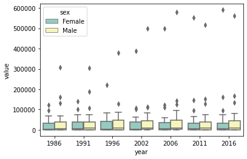

```python
# Density Plot and Histogram of all year datasets
ax = sns.boxplot(x="year", y="value", hue="sex",
                 data=df_mobility_by_past30yrs, palette="Set3")

def desc_stats(df):
    mean = df['value'].mean()
    median = df['value'].median()
    mode = df['value'].mode()
    std = df['value'].std()
    cov = std / mean
    print ("mean: " + str(mean) + ",\nmedian: " + str(median) + ",\nstd dev: " + str(std) + ",\ncoefficient of variation: " + str(cov) +"\n")
```

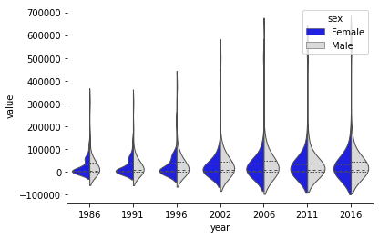

```python
# Draw a nested violinplot and split the violins for easier comparison
sns.violinplot(data=df_mobility_by_past30yrs, x="year", y="value", hue="sex",
               split=True, inner="quart", linewidth=1,
               palette={"Female": "b", "Male": ".85"})
sns.despine(left=True)
```

```python
desc_stats(df_mobility_by_past30yrs)
skewness_kurtosis(df_mobility_by_past30yrs)
```

```
mean: 33501.01587301587,
median: 6545.5,
std dev: 75254.41202447105,
coefficient of variation: 2.2463322398854886

Skew:
5.100932693490345
data is highly skewed

Kurtosis:
30.22457678237505
data has a leptokurtic distribution(tall+thin)
```

```python
df_30f = df_mobility_by_past30yrs.loc[df_mobility_by_past30yrs['sex'] == 'Female']
df_30m = df_mobility_by_past30yrs.loc[df_mobility_by_past30yrs['sex'] == 'Male']
```

#### Female distribution

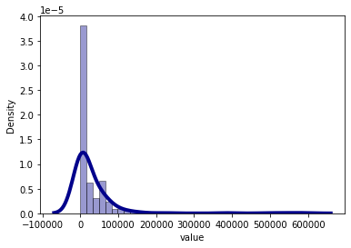

```python
sns.distplot(df_30f['value'], hist=True, kde=True,
             bins=int(180/5), color = 'darkblue',
             hist_kws={'edgecolor':'black'},
             kde_kws={'linewidth': 4})
```

#### Male distribution

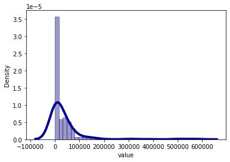

```python
sns.distplot(df_30m['value'], hist=True, kde=True,
             bins=int(180/5), color = 'darkblue',
             hist_kws={'edgecolor':'black'},
             kde_kws={'linewidth': 4})
```

```python
df_1986 = df_mobility_by_past30yrs.loc[df_mobility_by_past30yrs['year'] == 1986]
df_1991 = df_mobility_by_past30yrs.loc[df_mobility_by_past30yrs['year'] == 1991]
df_1996 = df_mobility_by_past30yrs.loc[df_mobility_by_past30yrs['year'] == 1996]
df_2002 = df_mobility_by_past30yrs.loc[df_mobility_by_past30yrs['year'] == 2002]
df_2006 = df_mobility_by_past30yrs.loc[df_mobility_by_past30yrs['year'] == 2006]
df_2011 = df_mobility_by_past30yrs.loc[df_mobility_by_past30yrs['year'] == 2011]
df_2016 = df_mobility_by_past30yrs.loc[df_mobility_by_past30yrs['year'] == 2016]

#split 30 year dataset into yearly datasets
mdf_30 = [df_1986,df_1991,df_1996,df_2002,df_2006,df_2011,df_2016]
```

```python
desc_stats(mdf_30[0])
skewness_kurtosis(mdf_30[0])
```

```
mean: 26643.083333333332,
median: 5427.5,
std dev: 47705.59310367328,
coefficient of variation: 1.7905432530771883

Skew:
3.586749125291121
data is highly skewed

Kurtosis:
17.278649078116537
data has a leptokurtic distribution(tall+thin)
```

### How commuting in Ireland changed from 1986 to 2016

### Overall Change in commuting

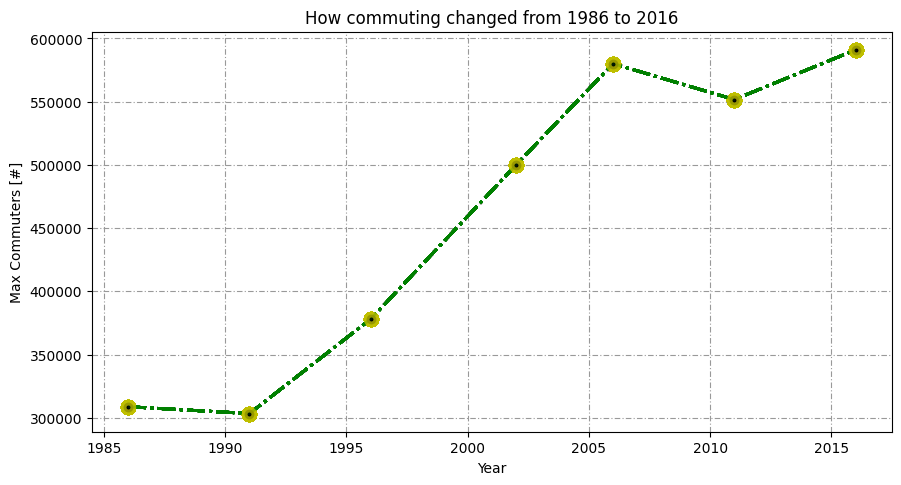

```python
fig_1 = plt.figure(figsize=(8,4), dpi=100)

ax_1 = fig_1.add_axes([0, 0, 1, 1])
x = []
y = []
for cen in mdf_30:
    x.append(cen.year)
    y.append(cen.value.max())

ax_1.set_xlabel('Year')
ax_1.set_ylabel('Max Commuters [#]')
ax_1.set_title('How commuting changed from 1986 to 2016')

ax_1.plot(
    x,
    y,
    color='green',
    alpha=.75,
    lw=2,
    ls='-.',
    marker='o',
    markersize=7,
    markerfacecolor='k',
    markeredgecolor='y',
    markeredgewidth=4
); #using ; to surpress output

#enables grid and sets spacing
ax_1.grid(True, color='0.6', dashes=(5, 2, 1, 2)) #5pts, 2 spaces, 1pt, 2 spaces

plt.tight_layout()
```

### How we commuted since 1986 to 2016

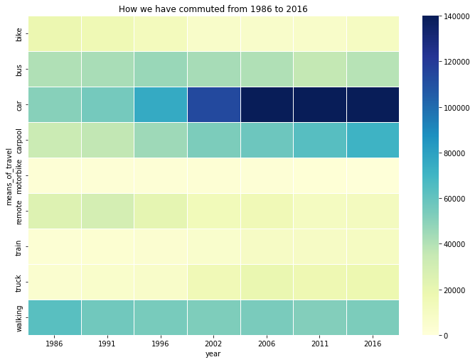

```python
how_we_travel = df_mobility_by_past30yrs.pivot_table(index='means_of_travel', columns='year', values='value')
a4_dims = (11.7, 8.27)
fig_2, ax_2 = plt.subplots(figsize=a4_dims)
ax_2.set_xlabel('Year')
ax_2.set_ylabel('How we commute')
ax_2.set_title('How we have commuted from 1986 to 2016')
sns.heatmap(
            ax=ax_2,
            data=how_we_travel,
            vmin=0,
            vmax=140000,
            linewidths=.5,
            cmap='YlGnBu');
```

- Over the years we have had to increasingly rely on cars for mobility both as drivers or through carpooling. We have also seen more trucks on the road.
- Although it has decreased slightly we still walk everywhere if we are not driving.
- Our cycling use has decreased and so has our bus use. There was no real change in motorbike use.
- Remote work in this case includes those working on their own farms and those who were homemakers. More woman in the workplace and those leaving farms to take up work in the city could help explain why working remotely has decreased. Cenus data are taken every 5 years. This data is before covid so in a future dataset we may see this sharply increase.

### Who did the commuting & how

[figure not shown]

```python
# ref https://matplotlib.org/stable/gallery/lines_bars_and_markers/barchart.html
fig_3, ax_3 = plt.subplots(figsize=(20, 36), nrows=7) # we create a subplot

# Add some text for labels, title and custom x-axis tick labels, etc.
year = 1986
width = 0.45  # the width of the bars

for i in range(7):
    year = year if i==0 else year + 5

    #We create a table of males and females indexed by means of travel
    who_travels = mdf_30[i].pivot_table(index='means_of_travel', columns='sex', values='value')
    x = np.arange(len(who_travels.index))  # the label locations

    males = ax_3[i].bar(x - width/2, who_travels.Male, width, label='Men')
    females = ax_3[i].bar(x + width/2, who_travels.Female, width, label='Women')
    ax_3[i].set_ylabel('Commuters [#]')

    ax_3[i].set_title('How we got around in ' + str(year))
    ax_3[i].set_xticks(x)
    ax_3[i].set_xticklabels(who_travels.index)
    ax_3[i].legend()
    ax_3[i].bar_label(males, padding=3)
    ax_3[i].bar_label(females, padding=3)


fig_3.tight_layout()
plt.show()
```

### Difference between Males & Females when Commuting

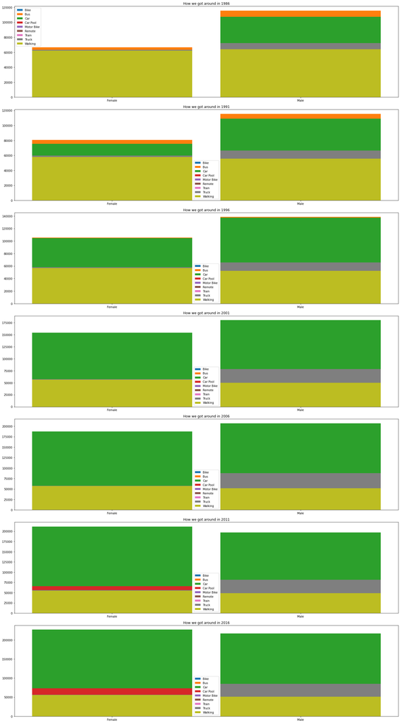

```python
fig_4, ax_4 = plt.subplots(figsize=(20, 36), nrows=7) # we create a subplot

# Add some text for labels, title and custom x-axis tick labels, etc.
year = 1986
width = 0.85  # the width of the bars

for i in range(7):
    year = year if i==0 else year + 5

    who_travels = mdf_30[i].pivot_table(index='sex', columns='means_of_travel', values='value')
    x = np.arange(len(who_travels.index))  # the label locations
    ax_4[i].set_xticks(x-width)
    ax_4[i].set_xticklabels(who_travels.index)
    ax_4[i].set_title('How we got around in ' + str(year))

    ax_4[i].bar(x-width, who_travels.bike,width, label='Bike', bottom=who_travels.bus);
    ax_4[i].bar(x-width, who_travels.bus,width, label='Bus', bottom=who_travels.car);
    ax_4[i].bar(x-width, who_travels.car,width, label='Car', bottom=who_travels.carpool);
    ax_4[i].bar(x-width, who_travels.carpool,width, label='Car Pool', bottom=who_travels.motorbike);
    ax_4[i].bar(x-width, who_travels.motorbike,width, label='Motor Bike', bottom=who_travels.remote);
    ax_4[i].bar(x-width, who_travels.remote,width, label='Remote', bottom=who_travels.train);
    ax_4[i].bar(x-width, who_travels.train,width, label='Train', bottom=who_travels.truck);
    ax_4[i].bar(x-width, who_travels.truck,width, label='Truck', bottom=who_travels.walking);
    ax_4[i].bar(x-width, who_travels.walking,width, label='Walking');

    ax_4[i].legend();

fig_4.tight_layout()
plt.show()
```

#### How females got around

- From the stacked bar charts we can see that females originally walked more or used public transport, they hardly drove.
- As the years passed they used cars more and walking less. It could be due to females leaving the home and working in towns.
- Interestingly we see carpooling more amoung females increase and with public transport decrease. It could be explained by safety related issues.

#### How males got around

- similarly to females we see public transport used less over the years.
- Car usage increase while walking decreased. It could be due to males getting work in towns instead of on farms.
- Truck usage amoung males also increased, this includes vans. Here, we assume it is also work related.

### Age and education of those commuting

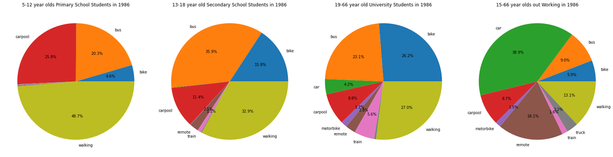

```python
i = 0
year = 1986

# Make figure and axes
fig_5, ax_5 = plt.subplots(
    figsize=(23, 20),
    nrows=1,
    ncols=4,
)

#custom percentage formatter
def age_autopct(pct):
    return ('%1.1f%%' % pct) if pct > 1 else ''

ax = ax_5

# age_range, edu_status
who_travels = mdf_30[i].pivot_table(index='means_of_travel', columns='age_range', values='value')
ages = mdf_30[i]['age_range'].unique()

# 5-12 pie plot
ax[0].set_title("5-12 year olds Primary School Students in " + str(year))
ax[0].pie(
    who_travels["5-12"],
    #we set a condition to remove any labels where values are less than 1%
    labels=[n if v > who_travels["5-12"].sum() * 0.01 else ''
              for n, v in zip(who_travels.index, who_travels["5-12"])],
    autopct=age_autopct)

# 13-18 pie plot
ax[1].set_title("13-18 year old Secondary School Students in " + str(year))
ax[1].pie(
    who_travels["13-18"],
    #we set a condition to remove any labels where values are less than 1%
    labels=[n if v > who_travels["13-18"].sum() * 0.01 else ''
              for n, v in zip(who_travels.index, who_travels["13-18"])],
    autopct=age_autopct)

# 19-66 pie plot
ax[2].set_title("19-66 year old University Students in " + str(year))
ax[2].pie(
    who_travels["19-66"],
    #we set a condition to remove any labels where values are less than 1%
    labels=[n if v > who_travels["19-66"].sum() * 0.01 else ''
              for n, v in zip(who_travels.index, who_travels["19-66"])],
    autopct=age_autopct)

# 15-66 pie plot
ax[3].set_title("15-66 year olds out Working in " + str(year))
ax[3].pie(
    who_travels["15-66"],
    #we set a condition to remove any labels where values are less than 1%
    labels=[n if v > who_travels["15-66"].sum() * 0.01 else ''
              for n, v in zip(who_travels.index, who_travels["15-66"])],
    autopct=age_autopct)

fig_5.tight_layout()
fig_5.subplots_adjust(hspace=.5)
```

#### Child, Student and Adult Commuters in 1986

- Children mostly walked to school, got the bus or carpooled.
- As they got older they car pooled less and walked less, relying more on public transport or biking
- As young adults they either biked, took public transport or biked to university, not may had a car
- As adults they mostly drove, worked at home or on the farm

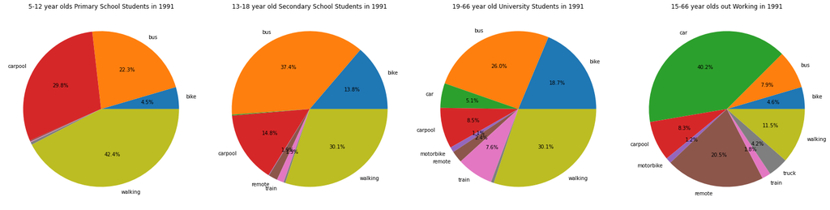

```python
i = 1
year = 1991

# Make figure and axes
fig_6, ax_6 = plt.subplots(
    figsize=(23, 20),
    nrows=1,
    ncols=4,
)

#custom percentage formatter
def age_autopct(pct):
    return ('%1.1f%%' % pct) if pct > 1 else ''

ax = ax_6

# age_range, edu_status
who_travels = mdf_30[i].pivot_table(index='means_of_travel', columns='age_range', values='value')
ages = mdf_30[i]['age_range'].unique()

# 5-12 pie plot
ax[0].set_title("5-12 year olds Primary School Students in " + str(year))
ax[0].pie(
    who_travels["5-12"],
    #we set a condition to remove any labels where values are less than 1%
    labels=[n if v > who_travels["5-12"].sum() * 0.01 else ''
              for n, v in zip(who_travels.index, who_travels["5-12"])],
    autopct=age_autopct)

# 13-18 pie plot
ax[1].set_title("13-18 year old Secondary School Students in " + str(year))
ax[1].pie(
    who_travels["13-18"],
    #we set a condition to remove any labels where values are less than 1%
    labels=[n if v > who_travels["13-18"].sum() * 0.01 else ''
              for n, v in zip(who_travels.index, who_travels["13-18"])],
    autopct=age_autopct)

# 19-66 pie plot
ax[2].set_title("19-66 year old University Students in " + str(year))
ax[2].pie(
    who_travels["19-66"],
    #we set a condition to remove any labels where values are less than 1%
    labels=[n if v > who_travels["19-66"].sum() * 0.01 else ''
              for n, v in zip(who_travels.index, who_travels["19-66"])],
    autopct=age_autopct)

# 15-66 pie plot
ax[3].set_title("15-66 year olds out Working in " + str(year))
ax[3].pie(
    who_travels["15-66"],
    #we set a condition to remove any labels where values are less than 1%
    labels=[n if v > who_travels["15-66"].sum() * 0.01 else ''
              for n, v in zip(who_travels.index, who_travels["15-66"])],
    autopct=age_autopct)

fig_6.tight_layout()
fig_6.subplots_adjust(hspace=.5)
```

#### Child, Student and Adult Commuters in 1991

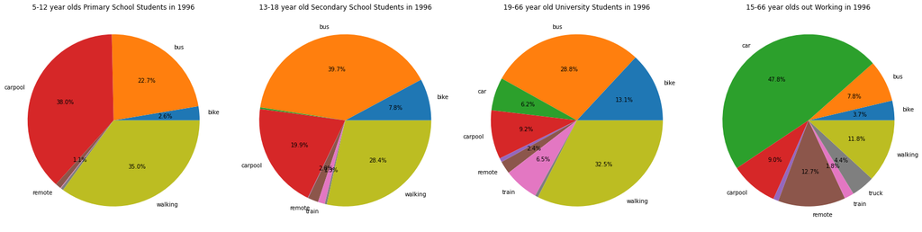

```python
i = 2
year = 1996

# Make figure and axes
fig_7, ax_7 = plt.subplots(
    figsize=(23, 20),
    nrows=1,
    ncols=4,
)

#custom percentage formatter
def age_autopct(pct):
    return ('%1.1f%%' % pct) if pct > 1 else ''

ax = ax_7

# age_range, edu_status
who_travels = mdf_30[i].pivot_table(index='means_of_travel', columns='age_range', values='value')
ages = mdf_30[i]['age_range'].unique()

# 5-12 pie plot
ax[0].set_title("5-12 year olds Primary School Students in " + str(year))
ax[0].pie(
    who_travels["5-12"],
    #we set a condition to remove any labels where values are less than 1%
    labels=[n if v > who_travels["5-12"].sum() * 0.01 else ''
              for n, v in zip(who_travels.index, who_travels["5-12"])],
    autopct=age_autopct)

# 13-18 pie plot
ax[1].set_title("13-18 year old Secondary School Students in " + str(year))
ax[1].pie(
    who_travels["13-18"],
    #we set a condition to remove any labels where values are less than 1%
    labels=[n if v > who_travels["13-18"].sum() * 0.01 else ''
              for n, v in zip(who_travels.index, who_travels["13-18"])],
    autopct=age_autopct)

# 19-66 pie plot
ax[2].set_title("19-66 year old University Students in " + str(year))
ax[2].pie(
    who_travels["19-66"],
    #we set a condition to remove any labels where values are less than 1%
    labels=[n if v > who_travels["19-66"].sum() * 0.01 else ''
              for n, v in zip(who_travels.index, who_travels["19-66"])],
    autopct=age_autopct)

# 15-66 pie plot
ax[3].set_title("15-66 year olds out Working in " + str(year))
ax[3].pie(
    who_travels["15-66"],
    #we set a condition to remove any labels where values are less than 1%
    labels=[n if v > who_travels["15-66"].sum() * 0.01 else ''
              for n, v in zip(who_travels.index, who_travels["15-66"])],
    autopct=age_autopct)

fig_7.tight_layout()
fig_7.subplots_adjust(hspace=.5)
```

#### Child, Student and Adult Commuters in 1996

- Public transport is used a little bit more but children walk less.
- Public transport is used more among young adults along with carpooling. They are walking more and we see an increase in personal car use.
- increasingly cars are needed to work, less remote work is happening.

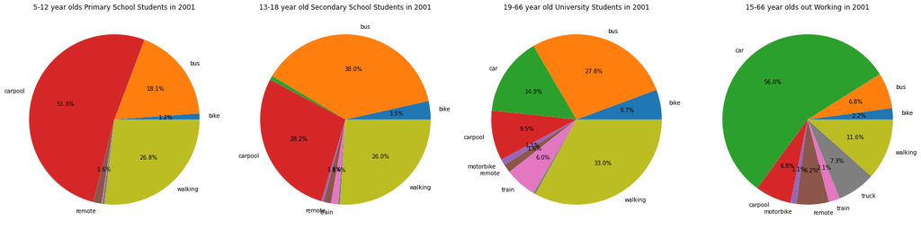

```python
i = 3
year = 2001

# Make figure and axes
fig_8, ax_8 = plt.subplots(
    figsize=(23, 20),
    nrows=1,
    ncols=4,
)

#custom percentage formatter
def age_autopct(pct):
    return ('%1.1f%%' % pct) if pct > 1 else ''

ax = ax_8

# age_range, edu_status
who_travels = mdf_30[i].pivot_table(index='means_of_travel', columns='age_range', values='value')
ages = mdf_30[i]['age_range'].unique()

# 5-12 pie plot
ax[0].set_title("5-12 year olds Primary School Students in " + str(year))
ax[0].pie(
    who_travels["5-12"],
    #we set a condition to remove any labels where values are less than 1%
    labels=[n if v > who_travels["5-12"].sum() * 0.01 else ''
              for n, v in zip(who_travels.index, who_travels["5-12"])],
    autopct=age_autopct)

# 13-18 pie plot
ax[1].set_title("13-18 year old Secondary School Students in " + str(year))
ax[1].pie(
    who_travels["13-18"],
    #we set a condition to remove any labels where values are less than 1%
    labels=[n if v > who_travels["13-18"].sum() * 0.01 else ''
              for n, v in zip(who_travels.index, who_travels["13-18"])],
    autopct=age_autopct)

# 19-66 pie plot
ax[2].set_title("19-66 year old University Students in " + str(year))
ax[2].pie(
    who_travels["19-66"],
    #we set a condition to remove any labels where values are less than 1%
    labels=[n if v > who_travels["19-66"].sum() * 0.01 else ''
              for n, v in zip(who_travels.index, who_travels["19-66"])],
    autopct=age_autopct)

# 15-66 pie plot
ax[3].set_title("15-66 year olds out Working in " + str(year))
ax[3].pie(
    who_travels["15-66"],
    #we set a condition to remove any labels where values are less than 1%
    labels=[n if v > who_travels["15-66"].sum() * 0.01 else ''
              for n, v in zip(who_travels.index, who_travels["15-66"])],
    autopct=age_autopct)

fig_8.tight_layout()
fig_8.subplots_adjust(hspace=.5)
```

#### Child, Student and Adult Commuters in 2001

- carpooling children and young adults increases, they walk less
- Use of trains for public transport is hardly used

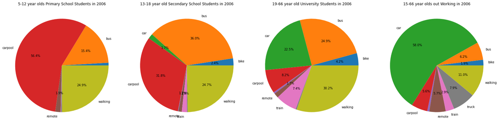

```python
i = 4
year = 2006

# Make figure and axes
fig_9, ax_9 = plt.subplots(
    figsize=(23, 20),
    nrows=1,
    ncols=4,
)

#custom percentage formatter
def age_autopct(pct):
    return ('%1.1f%%' % pct) if pct > 1 else ''

ax = ax_9

# age_range, edu_status
who_travels = mdf_30[i].pivot_table(index='means_of_travel', columns='age_range', values='value')
ages = mdf_30[i]['age_range'].unique()

# 5-12 pie plot
ax[0].set_title("5-12 year olds Primary School Students in " + str(year))
ax[0].pie(
    who_travels["5-12"],
    #we set a condition to remove any labels where values are less than 1%
    labels=[n if v > who_travels["5-12"].sum() * 0.01 else ''
              for n, v in zip(who_travels.index, who_travels["5-12"])],
    autopct=age_autopct)

# 13-18 pie plot
ax[1].set_title("13-18 year old Secondary School Students in " + str(year))
ax[1].pie(
    who_travels["13-18"],
    #we set a condition to remove any labels where values are less than 1%
    labels=[n if v > who_travels["13-18"].sum() * 0.01 else ''
              for n, v in zip(who_travels.index, who_travels["13-18"])],
    autopct=age_autopct)

# 19-66 pie plot
ax[2].set_title("19-66 year old University Students in " + str(year))
ax[2].pie(
    who_travels["19-66"],
    #we set a condition to remove any labels where values are less than 1%
    labels=[n if v > who_travels["19-66"].sum() * 0.01 else ''
              for n, v in zip(who_travels.index, who_travels["19-66"])],
    autopct=age_autopct)

# 15-66 pie plot
ax[3].set_title("15-66 year olds out Working in " + str(year))
ax[3].pie(
    who_travels["15-66"],
    #we set a condition to remove any labels where values are less than 1%
    labels=[n if v > who_travels["15-66"].sum() * 0.01 else ''
              for n, v in zip(who_travels.index, who_travels["15-66"])],
    autopct=age_autopct)

fig_9.tight_layout()
fig_9.subplots_adjust(hspace=.5)
```

#### Child, Student and Adult Commuters in 2006

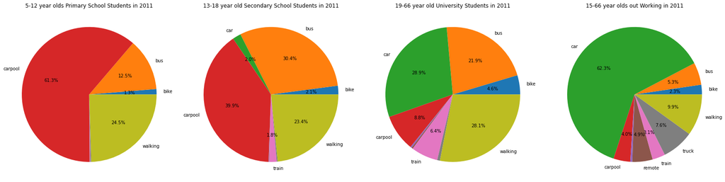

```python
i = 5
year = 2011

# Make figure and axes
fig_10, ax_10 = plt.subplots(
    figsize=(23, 20),
    nrows=1,
    ncols=4,
)

#custom percentage formatter
def age_autopct(pct):
    return ('%1.1f%%' % pct) if pct > 1 else ''

ax = ax_10

# age_range, edu_status
who_travels = mdf_30[i].pivot_table(index='means_of_travel', columns='age_range', values='value')
ages = mdf_30[i]['age_range'].unique()

# 5-12 pie plot
ax[0].set_title("5-12 year olds Primary School Students in " + str(year))
ax[0].pie(
    who_travels["5-12"],
    #we set a condition to remove any labels where values are less than 1%
    labels=[n if v > who_travels["5-12"].sum() * 0.01 else ''
              for n, v in zip(who_travels.index, who_travels["5-12"])],
    autopct=age_autopct)

# 13-18 pie plot
ax[1].set_title("13-18 year old Secondary School Students in " + str(year))
ax[1].pie(
    who_travels["13-18"],
    #we set a condition to remove any labels where values are less than 1%
    labels=[n if v > who_travels["13-18"].sum() * 0.01 else ''
              for n, v in zip(who_travels.index, who_travels["13-18"])],
    autopct=age_autopct)

# 19-66 pie plot
ax[2].set_title("19-66 year old University Students in " + str(year))
ax[2].pie(
    who_travels["19-66"],
    #we set a condition to remove any labels where values are less than 1%
    labels=[n if v > who_travels["19-66"].sum() * 0.01 else ''
              for n, v in zip(who_travels.index, who_travels["19-66"])],
    autopct=age_autopct)

# 15-66 pie plot
ax[3].set_title("15-66 year olds out Working in " + str(year))
ax[3].pie(
    who_travels["15-66"],
    #we set a condition to remove any labels where values are less than 1%
    labels=[n if v > who_travels["15-66"].sum() * 0.01 else ''
              for n, v in zip(who_travels.index, who_travels["15-66"])],
    autopct=age_autopct)

fig_10.tight_layout()
fig_10.subplots_adjust(hspace=.5)
```

#### Child, Student and Adult Commuters in 2011

- Carpooling dominates how we bring our kids to school, with public transport relied on less.
- Children are still driven to school even as they become young adults.
- Young adults use their own personal car, walk or bike to get to university. Public transport is avoided more.
- The car takes center stage in how we make a living.

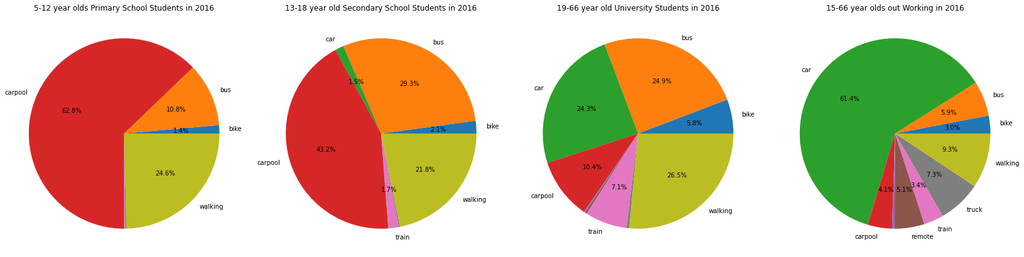

```python
i = 6
year = 2016

# Make figure and axes
fig_11, ax_11 = plt.subplots(
    figsize=(23, 20),
    nrows=1,
    ncols=4,
)

#custom percentage formatter
def age_autopct(pct):
    return ('%1.1f%%' % pct) if pct > 1 else ''

ax = ax_11

# age_range, edu_status
who_travels = mdf_30[i].pivot_table(index='means_of_travel', columns='age_range', values='value')
ages = mdf_30[i]['age_range'].unique()

# 5-12 pie plot
ax[0].set_title("5-12 year olds Primary School Students in " + str(year))
ax[0].pie(
    who_travels["5-12"],
    #we set a condition to remove any labels where values are less than 1%
    labels=[n if v > who_travels["5-12"].sum() * 0.01 else ''
              for n, v in zip(who_travels.index, who_travels["5-12"])],
    autopct=age_autopct)

# 13-18 pie plot
ax[1].set_title("13-18 year old Secondary School Students in " + str(year))
ax[1].pie(
    who_travels["13-18"],
    #we set a condition to remove any labels where values are less than 1%
    labels=[n if v > who_travels["13-18"].sum() * 0.01 else ''
              for n, v in zip(who_travels.index, who_travels["13-18"])],
    autopct=age_autopct)

# 19-66 pie plot
ax[2].set_title("19-66 year old University Students in " + str(year))
ax[2].pie(
    who_travels["19-66"],
    #we set a condition to remove any labels where values are less than 1%
    labels=[n if v > who_travels["19-66"].sum() * 0.01 else ''
              for n, v in zip(who_travels.index, who_travels["19-66"])],
    autopct=age_autopct)

# 15-66 pie plot
ax[3].set_title("15-66 year olds out Working in " + str(year))
ax[3].pie(
    who_travels["15-66"],
    #we set a condition to remove any labels where values are less than 1%
    labels=[n if v > who_travels["15-66"].sum() * 0.01 else ''
              for n, v in zip(who_travels.index, who_travels["15-66"])],
    autopct=age_autopct)

fig_11.tight_layout()
fig_11.subplots_adjust(hspace=.5)
```

#### Child, Student and Adult Commuters in 2016

- Carpooling last longer for children as they progress into secondary school then young adults either walk, use the bus or get their own car.
- The car dominates how people make a living from work.

### What commuters do for a living 2016

```python
df_people_at_work.head()
```

|  | year | principal_economic_status | sex | value |
| --- | --- | --- | --- | --- |
| 0 | 2016 | self-employed | Male | 238430 |
| 1 | 2016 | self-employed | Female | 69981 |
| 2 | 2016 | employee | Male | 816943 |
| 3 | 2016 | employee | Female | 840801 |
| 4 | 2016 | carer | Male | 2192 |

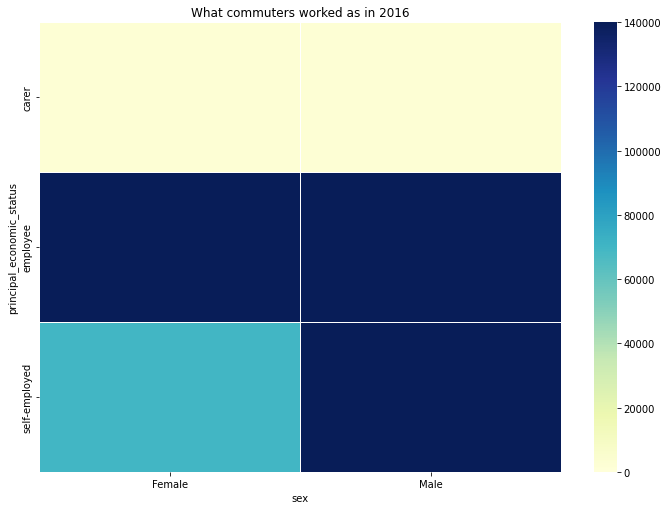

```python
jobs_of_working_commuters = df_people_at_work.pivot_table(index='principal_economic_status', columns='sex', values='value')
a4_dims = (11.7, 8.27)
fig_2, ax_2 = plt.subplots(figsize=a4_dims)
ax_2.set_xlabel('Year')
ax_2.set_ylabel('How we commute')
ax_2.set_title('What commuters worked as in 2016')
sns.heatmap(
            ax=ax_2,
            data=jobs_of_working_commuters,
            vmin=0,
            vmax=140000,
            linewidths=.5,
            cmap='YlGnBu');
```

- Majority of self employed are males. Over 120,000 are female and male employees
- Male & Females equally work as carers but this is less than 20,000.
- Possibly the majority of self employed are tradesmen going to and from work.

```python
#df_mobility_by_class.hea
```

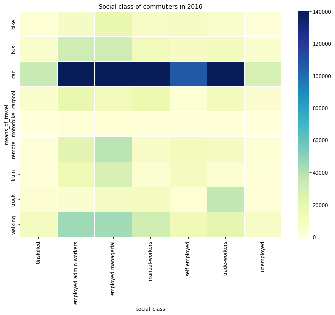

```python
df_2016sc = df_mobility_by_class.loc[df_mobility_by_class['year'] == 2016]

social_class_of_commuters = df_2016sc.pivot_table(index='means_of_travel', columns='social_class', values='value')
a4_dims = (11.7, 8.27)
fig_2, ax_2 = plt.subplots(figsize=a4_dims)
ax_2.set_xlabel('Year')
ax_2.set_ylabel('How we commute')
ax_2.set_title('Social class of commuters in 2016')
sns.heatmap(
            ax=ax_2,
            data=social_class_of_commuters,
            vmin=0,
            vmax=140000,
            linewidths=.5,
            cmap='YlGnBu');
```

- Car usage is dominated by trade workers, manual workers and employees of companies

```python
df_travel_duration.head()
```

|  | year | sex | travelling_time | time_leaving_home | age_range | edu_status | value |
| --- | --- | --- | --- | --- | --- | --- | --- |
| 0 | 2011 | Male | 0.125 | -1.00 | 15-66 | working | 209852 |
| 1 | 2011 | Male | 0.125 | -1.00 | 5-12 | at primary school | 168826 |
| 2 | 2011 | Male | 0.125 | -1.00 | 13-18 | at secondary school | 61830 |
| 3 | 2011 | Male | 0.125 | -1.00 | 19-66 | at university | 20799 |
| 4 | 2011 | Male | 0.125 | 6.15 | 15-66 | working | 17173 |

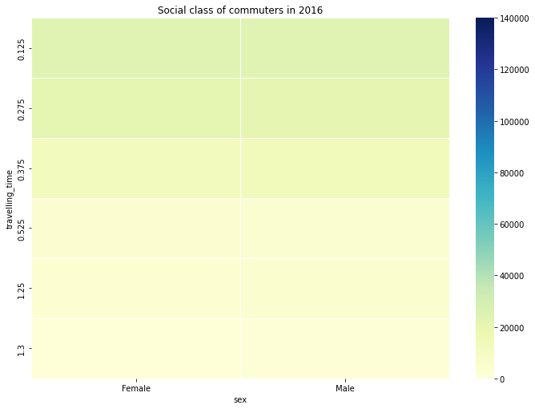

```python
df_2016td = df_travel_duration.loc[df_travel_duration['year'] == 2016]

#time chart showing travel time from 2011 to 2016?
commuters_travelling = df_2016td.pivot_table(index='travelling_time', columns='sex', values='value')
a4_dims = (11.7, 8.27)
fig_2, ax_2 = plt.subplots(figsize=a4_dims)
ax_2.set_xlabel('Year')
ax_2.set_ylabel('How we commute')
ax_2.set_title('Social class of commuters in 2016')
sns.heatmap(
            ax=ax_2,
            data=commuters_travelling,
            vmin=0,
            vmax=140000,
            linewidths=.5,
            cmap='YlGnBu');
```

```python
df_travel_time_by_age.head()
```

|  | year | age_group | sex | travelling_time | value |
| --- | --- | --- | --- | --- | --- |
| 0 | 2011 | 15 - 19 years | Male | 0.125 | 2266 |
| 1 | 2011 | 15 - 19 years | Male | 0.275 | 2262 |
| 2 | 2011 | 15 - 19 years | Male | 0.375 | 1301 |
| 3 | 2011 | 15 - 19 years | Male | 0.525 | 328 |
| 4 | 2011 | 15 - 19 years | Male | 1.250 | 357 |

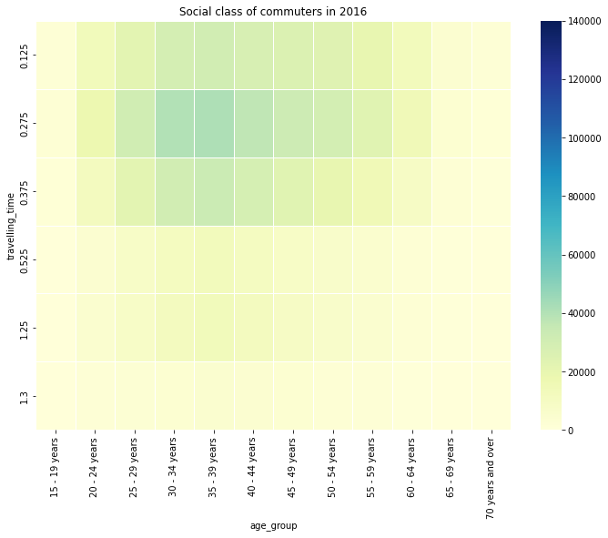

```python
df_2016tta = df_travel_time_by_age.loc[df_travel_time_by_age['year'] == 2016]

#time chart showing travel time from 2011 to 2016?
commuters_travelling = df_2016tta.pivot_table(index='travelling_time', columns='age_group', values='value')
a4_dims = (11.7, 8.27)
fig_2, ax_2 = plt.subplots(figsize=a4_dims)
ax_2.set_xlabel('Year')
ax_2.set_ylabel('How we commute')
ax_2.set_title('Social class of commuters in 2016')
sns.heatmap(
            ax=ax_2,
            data=commuters_travelling,
            vmin=0,
            vmax=140000,
            linewidths=.5,
            cmap='YlGnBu');
```

```python
df_mobility_by_students.head()
```

|  | year | sex | means_of_travel | aggregate_town_or_rural_area | time_leaving_home | age_range | edu_status | value |
| --- | --- | --- | --- | --- | --- | --- | --- | --- |
| 0 | 2011 | Male | walking | Aggregate Town Area | 6.15 | 15-66 | working | 3621 |
| 1 | 2011 | Male | walking | Aggregate Town Area | 6.15 | 5-12 | at primary school | 23 |
| 2 | 2011 | Male | walking | Aggregate Town Area | 6.15 | 13-18 | at secondary school | 22 |
| 3 | 2011 | Male | walking | Aggregate Town Area | 6.15 | 19-66 | at university | 118 |
| 4 | 2011 | Male | walking | Aggregate Town Area | 6.45 | 15-66 | working | 3983 |

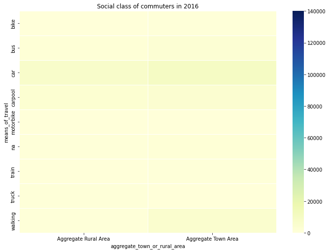

```python
df_2016sm = df_mobility_by_students.loc[df_mobility_by_students['year'] == 2016]

#time chart showing travel time from 2011 to 2016?
commuters_travelling = df_2016sm.pivot_table(index='means_of_travel', columns='aggregate_town_or_rural_area', values='value')
a4_dims = (11.7, 8.27)
fig_2, ax_2 = plt.subplots(figsize=a4_dims)
ax_2.set_xlabel('Year')
ax_2.set_ylabel('How we commute')
ax_2.set_title('Social class of commuters in 2016')
sns.heatmap(
            ax=ax_2,
            data=commuters_travelling,
            vmin=0,
            vmax=140000,
            linewidths=.5,
            cmap='YlGnBu');
```

- walking in towns than rural areas

```python
df_people_working_in_towns_suburbs.head()
```

|  | year | towns_suburbs | value |
| --- | --- | --- | --- |
| 0 | 2016 | Dublin City and suburbs | 422354 |
| 1 | 2016 | Cork City and suburbs | 72747 |
| 2 | 2016 | Limerick City and suburbs | 28543 |
| 3 | 2016 | Galway City and suburbs | 27836 |
| 4 | 2016 | Waterford City and suburbs | 16610 |

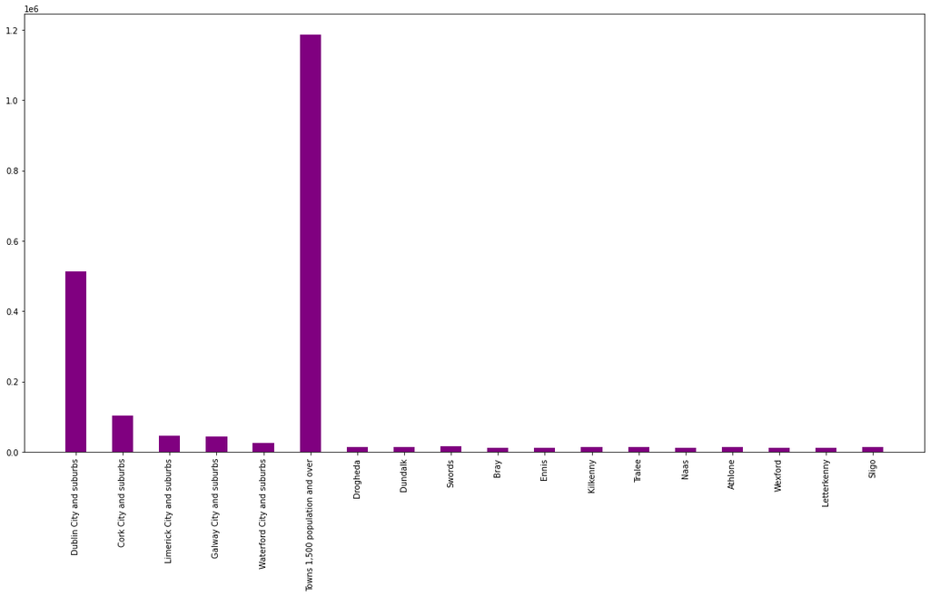

```python
plt.figure(figsize=(20, 10)) #used to space out x axis columns
df_2016ts = df_people_working_in_towns_suburbs.loc[df_people_working_in_towns_suburbs['value'] > 10000]
plt.bar(df_2016ts.towns_suburbs, df_2016ts.value,width=0.45, color='purple')
plt.xticks(rotation=90);
```

#### Where most commuters live in 2016

- most commuting live in towns fo 1,500 people or more, in dublin city, cork city, limerick city, galway city and waterford city

df_mobility_by_students_from_towns.head()

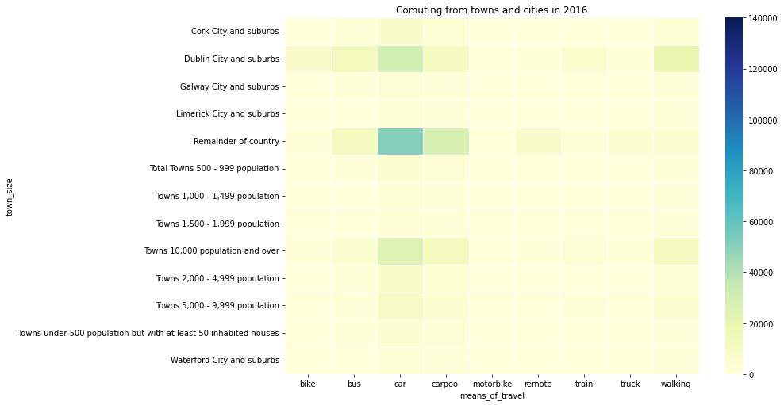

```python
df_2016mft = df_mobility_by_students_from_towns.loc[df_mobility_by_students_from_towns['year'] == 2016]

commuters_travelling = df_2016mft.pivot_table(index='town_size', columns='means_of_travel', values='value')
a4_dims = (11.7, 8.27)
fig_2, ax_2 = plt.subplots(figsize=a4_dims)
ax_2.set_xlabel('Year')
ax_2.set_ylabel('How we commute')
ax_2.set_title('Comuting from towns and cities in 2016')
sns.heatmap(
            ax=ax_2,
            data=commuters_travelling,
            vmin=0,
            vmax=140000,
            linewidths=.5,
            cmap='YlGnBu');
```

- We don't see public transport used from towns, or heavy use of tains.
- We see walking is high in towns
- The rest of the country outside of large towns and cities requires either their own car or to carpool with someone

```python
df_mobility_by_students_from_geo.head()
```

|  | year | sex | home | travelling_time | age_range | edu_status | value |
| --- | --- | --- | --- | --- | --- | --- | --- |
| 0 | 2011 | Male | Carlow | 0.125 | 15-66 | working | 2985 |
| 1 | 2011 | Male | Carlow | 0.125 | 5-12 | at primary school | 2226 |
| 2 | 2011 | Male | Carlow | 0.125 | 13-18 | at secondary school | 863 |
| 3 | 2011 | Male | Carlow | 0.125 | 19-66 | at university | 440 |
| 4 | 2011 | Male | Carlow | 0.275 | 15-66 | working | 2344 |

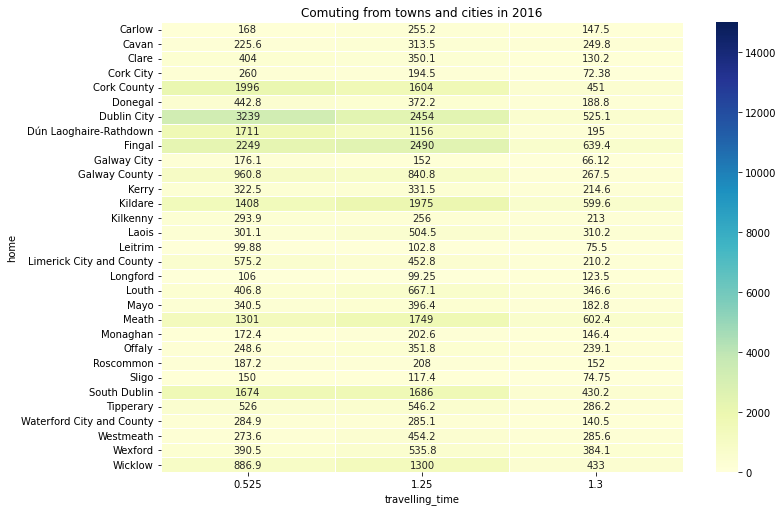

```python
df_2016mfg = df_mobility_by_students_from_geo.loc[df_mobility_by_students_from_geo['year'] == 2016]
#shows towns where it takes an hour to commute from
df_2016mfg = df_2016mfg.loc[df_2016mfg['travelling_time'] >= .5]

df_2016mfg.sort_values('value')
commuters_travelling = df_2016mfg.pivot_table(index='home', columns='travelling_time', values='value')
a4_dims = (11.7, 8.27)
fig_2, ax_2 = plt.subplots(figsize=a4_dims)
ax_2.set_xlabel('Year')
ax_2.set_ylabel('How we commute')
ax_2.set_title('Comuting from towns and cities in 2016')
sns.heatmap(
            ax=ax_2,
            data=commuters_travelling,
            vmin=0,
            vmax=15000,
            linewidths=.5,
            annot=True,
            fmt=".4g",
            cmap='YlGnBu');
```

- Commuters in dublin city, meath, fingal, south dubin, County Cork, Kildare and Wicklow experience commuting over an hour more than the rest of the country

### Summary Conclusion of Data Exploration

#### What the data shows

- Commuters rely heavily on personal transportation or commercial vehicles (e.g vans) to earn a living in Ireland.
- Commuters are working less at home or on the farm.
- Commuters of ireland are walking and cycling less.
- Commuters transport via buses is declining and commuters hardly anyone is using trains
- Commuters are driving their kids to school well into leaving cert in secondary school. We see this with an increase of carpooling amoung females and a decrease of public transport.
- The use of cars as personal transport starts to increase as young adults in university and progresses to working life.
- Most Commuters who work are employees of a company while self employement is dominated by males
- Car usage is dominated by trade workers, manual workers and employees of companies.
- Most commuting live in towns fo 1,500 Commuters or more, in Dublin City, Cork city, Limerick city, galway city and waterford city
- Public transport is not used from towns as much and there is not a heavy use of trains.
- We see walking is high in towns.
- The rest of the country outside of large towns and cities requires either their own car or to carpool with someone.
- Commuters in Dublin City, Meath, Fingal, South Dubin, County Cork, Kildare and Wicklow experience commuting over an hour more than the rest of the country

#### Assumptions made from data

- More women entered the work force from 1986 and more families left farming to take up work in towns and cities.
- Comuters live futher away from towns and cities due to house prices so are unable to walk or have access to public transport.
- Quality of public transport in terms of duration to reach destination and safety of journey decreased so commuters were less likely to use it. No subways exist and no proper investment in train networks was made.
- Quality of national roads, regional roads and those in towns or cities was poor and increased traffic congestion which decreased road safety. This could be why we see a decline in cycling and little motorbike use.
- Majority of male self employeed workers are tradesmen commuting to and from work sites.

## Feature Subset Identified

The following features were selected for further analyis.

- distance from towns and cities
- duration of public transport
- types of workers driving
- age of road users
- home location of commuters

# Part 3 - Subset Data Analysis

In this section of the report we will focus on a particular subset of features we identfied in part 2. We will drill down into each, extracting details to answer a series of questions around how to reduce carbon emmiissions from Irish transportation.

Unfortunately, the data provided by CSO is heterogeneous. Each table is of a different size. Data was also very catigorical and ordinal in nature which made it difficult to generate scatter plots and do proper regression analysis.

Several attempts were made to create a master subset dataframe but all failed to retain useful insights. This report will attempt to examine E6013, E6006, E6040, E6016, E6018 and E6023 seperately and where applicable use common features as a means to interpret commonality among the subsets.

## Subset Precleaning

Data needed to be further cleaned after data exploration. It was quickly done in notepad++. using the following regex pattern .*help.*\r?\n Column header 'value' was changed to 'commuters'.

```python
df_mg = pd.read_csv(r'./data/E6013_mobility_by_geo_cleaned.csv')
df_mg = df_mg.loc[df_mg['year'] == 2016]
df_mg =  df_mg.sort_values(by="value", ascending=False)
df_mg = df_mg.rename(columns={'value': 'commuters'})

df_td = pd.read_csv(r'./data/E6006_travel_duration_cleaned_further.csv')
df_td = df_td.loc[df_td['year'] == 2016]
df_td =  df_td.sort_values(by="value", ascending=False)
df_td = df_td.rename(columns={'value': 'commuters'})

df_tta = pd.read_csv(r'./data/E6040_travel_time_by_age_cleaned.csv')
df_tta = df_tta.loc[df_tta['year'] == 2016]
df_tta =  df_tta.sort_values(by="value", ascending=False)
df_tta = df_tta.rename(columns={'value': 'commuters'})

df_mob = pd.read_csv(r'./data/E6016.mobility_by_students_cleaned.csv')#
df_mob = df_mob.loc[df_mob['year'] == 2016]
df_mob =  df_mob.sort_values(by="value", ascending=False)
df_mob = df_mob.rename(columns={'value': 'commuters'})

df_mobt = pd.read_csv(r'./data/E6018.mobility_by_students_from_towns_cleaned.csv')#
df_mobt = df_mobt.loc[df_mobt['year'] == 2016]
df_mobt =  df_mobt.sort_values(by="value", ascending=False)
df_mobt = df_mobt.rename(columns={'value': 'commuters'})

df_mobg = pd.read_csv(r'./data/E6023.mobility_by_students_from_geo_cleaned.csv')
df_mobg = df_mobg.loc[df_mobg['year'] == 2016]
df_mobg =  df_mobg.sort_values(by="value", ascending=False)
df_mobg = df_mobg.rename(columns={'value': 'commuters'})
```

```python
df_mg.head() # 17952, 7 #shape is shown in comments (rows, col)
```

|  | year | sex | means_of_travel | towns_by_size | age_range | edu_status | commuters |
| --- | --- | --- | --- | --- | --- | --- | --- |
| 13024 | 2016 | Female | car | Remainder of country | 15-66 | working | 212681 |
| 4864 | 2016 | Male | car | Remainder of country | 15-66 | working | 175769 |
| 4080 | 2016 | Male | car | Dublin City and suburbs | 15-66 | working | 117132 |
| 12240 | 2016 | Female | car | Dublin City and suburbs | 15-66 | working | 111490 |
| 5681 | 2016 | Male | carpool | Remainder of country | 5-12 | at primary school | 66480 |

```python
df_td.head() #384,7
```

|  | year | sex | travelling_time | time_leaving_home | age_range | edu_status | commuters |
| --- | --- | --- | --- | --- | --- | --- | --- |
| 405 | 2016 | Male | 0.125 | 8.45 | 5-12 | at primary school | 98099 |
| 597 | 2016 | Female | 0.125 | 8.45 | 5-12 | at primary school | 93625 |
| 624 | 2016 | Female | 0.275 | 8.15 | 15-66 | working | 65503 |
| 596 | 2016 | Female | 0.125 | 8.45 | 15-66 | working | 58457 |
| 628 | 2016 | Female | 0.275 | 8.45 | 15-66 | working | 58010 |

```python
df_tta.head() # 144,5
```

|  | year | age_group | sex | travelling_time | commuters |
| --- | --- | --- | --- | --- | --- |
| 187 | 2016 | 30 - 34 years | Female | 0.275 | 41923 |
| 199 | 2016 | 35 - 39 years | Female | 0.275 | 41900 |
| 193 | 2016 | 35 - 39 years | Male | 0.275 | 41180 |
| 181 | 2016 | 30 - 34 years | Male | 0.275 | 37940 |
| 211 | 2016 | 40 - 44 years | Female | 0.275 | 37173 |

```python
df_mob.head() #1440,8
```

|  | year | sex | means_of_travel | aggregate_town_or_rural_area | time_leaving_home | age_range | edu_status | commuters |
| --- | --- | --- | --- | --- | --- | --- | --- | --- |
| 2536 | 2016 | Female | car | Aggregate Town Area | 8.15 | 15-66 | working | 72959 |
| 2532 | 2016 | Female | car | Aggregate Town Area | 7.45 | 15-66 | working | 61027 |
| 1812 | 2016 | Male | car | Aggregate Town Area | 7.45 | 15-66 | working | 60142 |
| 2572 | 2016 | Female | car | Aggregate Rural Area | 8.15 | 15-66 | working | 57764 |
| 2540 | 2016 | Female | car | Aggregate Town Area | 8.45 | 15-66 | working | 56830 |

```python
df_mobg.head() #1488,7
```

|  | year | sex | home | travelling_time | age_range | edu_status | commuters |
| --- | --- | --- | --- | --- | --- | --- | --- |
| 1516 | 2016 | Male | Dublin City | 0.275 | 15-66 | working | 41491 |
| 2260 | 2016 | Female | Dublin City | 0.275 | 15-66 | working | 39191 |
| 1520 | 2016 | Male | Dublin City | 0.375 | 15-66 | working | 34814 |
| 2264 | 2016 | Female | Dublin City | 0.375 | 15-66 | working | 32640 |
| 1900 | 2016 | Male | Cork County | 0.275 | 15-66 | working | 26075 |

```python
df_mobt.head() #1040,7
```

|  | year | sex | means_of_travel | town_size | age_range | edu_status | commuters |
| --- | --- | --- | --- | --- | --- | --- | --- |
| 1868 | 2016 | Female | car | Remainder of country | 15-66 | working | 212681 |
| 1348 | 2016 | Male | car | Remainder of country | 15-66 | working | 175769 |
| 1300 | 2016 | Male | car | Dublin City and suburbs | 15-66 | working | 117132 |
| 1820 | 2016 | Female | car | Dublin City and suburbs | 15-66 | working | 111490 |
| 1320 | 2016 | Male | car | Towns 10,000 population and over | 15-66 | working | 97270 |

## Question 1 - Which commuters emmit CO$^{2}$ and which do not?

Using the (European Parlement, 2019) breakdown of vehicle emmissions we can sub divide our dataset into emmiters and non emmiters. Vehicle emmissions are listed as follows:

| Vehicle | % CO$^{2}$ |
| --- | --- |
| Cars | 60.7% |
| Trucks | 26.2% |
| Bus | 11.9% |
| Motorcycles | 1.2% |
| Trains | 0.5% |

This suggests that the following do not emit CO$^{2}$, in terms of transportation:

- Remote Working (Includes Homemaking)
- Walking
- Using a Bicycle

We will break the dataset up into two groups and drill down into each attribute.

```python
#emiters (e) and non-emitters (ne)
df_e = df_mg.query('means_of_travel in ["car", "truck", "bus", "motorbike", "train", "carpool"]')
#array(['car', 'carpool', 'truck', 'bus', 'train', 'motorbike'],
df_e.sort_values(by="commuters", ascending=False)
df_e = df_e[['year', 'sex', 'age_range', 'edu_status', 'towns_by_size', 'commuters', 'means_of_travel']]
df_e.head()
```

|  | year | sex | age_range | edu_status | towns_by_size | commuters | means_of_travel |
| --- | --- | --- | --- | --- | --- | --- | --- |
| 13024 | 2016 | Female | 15-66 | working | Remainder of country | 212681 | car |
| 4864 | 2016 | Male | 15-66 | working | Remainder of country | 175769 | car |
| 4080 | 2016 | Male | 15-66 | working | Dublin City and suburbs | 117132 | car |
| 12240 | 2016 | Female | 15-66 | working | Dublin City and suburbs | 111490 | car |
| 5681 | 2016 | Male | 5-12 | at primary school | Remainder of country | 66480 | carpool |

```
<BarContainer object of 11424 artists>
```

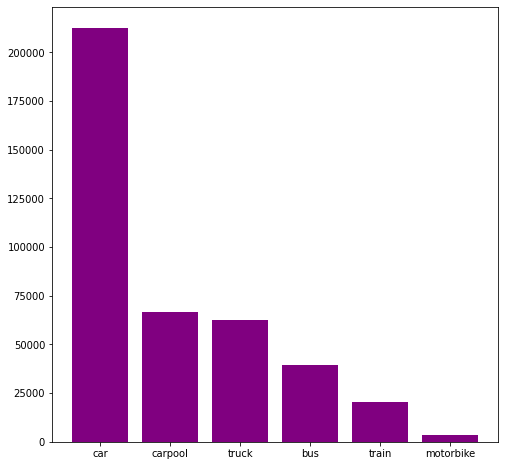

```python
plt.figure(figsize=(8, 8)) #used to space out x axis columns
plt.bar(df_e.means_of_travel, df_e.commuters, color='purple')
```

```python
pc = (df_e.commuters.sum()/(df_ne.commuters.sum() + df_e.commuters.sum()))*100
poluting_commuters = "{:.2f}".format(pc)

print(str(poluting_commuters) + "% are poluting commuters")
```

[output not shown]

```python
df_ne = df_mg.query('means_of_travel in ["remote", "walking", "bike"]')
df_ne.sort_values(by="commuters", ascending=False)
df_ne = df_ne[['year', 'sex', 'age_range', 'edu_status', 'towns_by_size', 'commuters', 'means_of_travel']]
df_ne.head()
```

```python
plt.figure(figsize=(8, 4)) #used to space out x axis columns
plt.bar(df_ne.means_of_travel, df_ne.commuters, color='green')
```

[output not shown]

```python
gc = (df_ne.commuters.sum()/(df_ne.commuters.sum() + df_e.commuters.sum()))*100
green_commuters = "{:.2f}".format(gc)

print(str(green_commuters) + "% are green commuters")
```

[output not shown]

## Question 2 - What is the relationship between commuters emmit CO$^{2}$ and means of travel?

### Chi-Square Test

We perform a chi-squred test to see if there is a statistically significant difference sex and means of travel for both emitters and non CO$^{2}$ emitters. We test to see if there is a significant relationship between two nominal variables by comparing their frequencies.

```python
contigency = pd.crosstab(df_e.sex, df_e.means_of_travel, df_e.commuters, aggfunc="sum", rownames=["sex"], colnames=[None])
#contigency.head()
plt.figure(figsize=(12,8))
sns.heatmap(contigency, annot=True, cmap="YlGnBu")
# Chi-square test of independence.
stat1, p1, dof1, expected1 = chi2_contingency(contigency)
```

[output not shown]

### Inference Sex vs Means of Travel

```python
alpha = 0.05

print('Significance=%.3f, p=%.3f' % (alpha, p1))
if p1 <= alpha:
    print('-> Variables are associated')
else:
    print('-> Variables are not associated')

# Print the p-value
print(p1)
```

[output not shown]

```python
contigency = pd.crosstab(df_e.age_range, df_e.means_of_travel, df_e.commuters, aggfunc="sum", rownames=["age_range"], colnames=[None])
#contigency.head()
plt.figure(figsize=(12,8))
sns.heatmap(contigency, annot=True, cmap="YlGnBu")
# Chi-square test of independence.
stat2, p2, dof2, expected2 = chi2_contingency(contigency)
```

[output not shown]

### Inference Age vs Means of Travel

```python
alpha = 0.05

print('Significance=%.3f, p=%.3f' % (alpha, p1))
if p2 <= alpha:
    print('-> Variables are associated')
else:
    print('-> Variables are not associated')

# Print the p-value
print(p2)
```

[output not shown]

```python
contigency = pd.crosstab(df_e.edu_status, df_e.means_of_travel, df_e.commuters, aggfunc="sum", rownames=["edu_status"], colnames=[None])
#contigency.head()
plt.figure(figsize=(12,8))
sns.heatmap(contigency, annot=True, cmap="YlGnBu")
# Chi-square test of independence.
stat3, p3, dof3, expected3 = chi2_contingency(contigency)
```

[output not shown]

### Inference education status vs Means of Travel

```python
alpha = 0.05

print('Significance=%.3f, p=%.3f' % (alpha, p1))
if p3 <= alpha:
    print('-> Variables are associated')
else:
    print('-> Variables are not associated')

# Print the p-value
print(p3)
```

[output not shown]

### Summary

From our Chi-Square test we found that Sex, age and education status are all interdependent on means of travel. We see men are more likely to emit more polution by means of driving heavy poluting vehicles while women more likely to avail of public transport. Working class adults and children make up a lot of car usage.

## Conclusion & Recommendations

Transportation accounts for 40% of Ireland's kilo tonne of CO$^{2}$ it puts into the atmosphere. This is affecting the climate and creating a green house gas effect which is raising global temperatures. This report asked how we could reduce CO$^{2}$ emissions by making changes to how we commute around Ireland.

We found out the following through data exploration:

- Commuters rely heavily on personal transportation or commercial vehicles (e.g vans) to earn a living in Ireland.
- Commuters are working less at home or on the farm.
- Commuters of ireland are walking and cycling less.
- Commuters transport via buses is declining and commuters hardly anyone is using trains
- Commuters are driving their kids to school well into leaving cert in secondary school. We see this with an increase of carpooling amoung females and a decrease of public transport.
- The use of cars as personal transport starts to increase as young adults in university and progresses to working life.
- Most Commuters who work are employees of a company while self employement is dominated by males
- Car usage is dominated by trade workers, manual workers and employees of companies.
- Most commuting live in towns fo 1,500 Commuters or more, in Dublin City, Cork city, Limerick city, galway city and waterford city
- Public transport is not used from towns as much and there is not a heavy use of trains.
- We see walking is high in towns.
- The rest of the country outside of large towns and cities requires either their own car or to carpool with someone.
- Commuters in Dublin City, Meath, Fingal, South Dubin, County Cork, Kildare and Wicklow experience commuting over an hour more than the rest of the country

We made the following assumptions on our findings:

- More women entered the work force from 1986 and more families left farming to take up work in towns and cities.
- Comuters live futher away from towns and cities due to house prices so are unable to walk or have access to public transport.
- Quality of public transport in terms of duration to reach destination and safety of journey decreased so commuters were less likely to use it. No subways exist and no proper investment in train networks was made.
- Quality of national roads, regional roads and those in towns or cities was poor and increased traffic congestion which decreased road safety. This could be why we see a decline in cycling and little motorbike use.
- Majority of male self employeed workers are tradesmen commuting to and from work sites.

We asked What was the relationship between commuters emmit CO$^{2}$ and means of travel. We found from our Chi-Square test that Sex, age and education status are all interdependent on means of travel. We saw men are more likely to emit more polution by means of driving heavy poluting vehicles while women more likely to avail of public transport or carpooling. Working class adults and children made up a lot of car usage.

This report recommends to reduce 20% of car usage by implementing the following:

- Invest in more train and subway access to increase walking among commuters.
- Allow working from home where possible amoung working class men.
- Invest in more bus networks to local schools and offer next ride free for parents to encourage them to take the bus to work.
- Improve quality of roads and security on bus networks to decrease the amount of carpooling amoung female commuters.
- Construct cycling lanes in all major towns and cities seperate from bus lanes.
- offer income tax reduction incentives to drivers of carpools and offer employee meal tax subsidies to businesses that promote carpooling or remote working among employees.
- Review latest cenus when complete to determine how many electric cars are used by commuters.
- Include more numeric data to complement CSO's categorical data.

# References

- EPA. (2021). What impact will climate change have on Ireland? Retrieved from epa.ie: https://www.epa.ie/environment-and-you/climate-change/what-impact-will-climate-change-have-for-ireland/
- European Parliament. (2019, 04 18). CO2 emissions from cars: facts and figures (infographics). Retrieved from europarl.europa.eu: https://www.europarl.europa.eu/news/en/headlines/society/20190313STO31218/co2-emissions-from-cars-facts-and-figures-infographics
- SEAI. (2021). Irelands CO₂ Emissions. Retrieved from seai.ie: https://www.seai.ie/data-and-insights/seai-statistics/key-statistics/co2/